# Extrahepatic blood supply to hepatocellular carcinoma: a meta-analysis and systematic review

Statistical report

**Authors and affiliations**

Roman Pavlov<sup>1,2</sup>, Adam Whitley<sup>2,3</sup>, David Kachlík<sup>2,4</sup>, Filip Tichanek<sup>5</sup>, Daniel Palouš<sup>1</sup>, and Theodor Adla<sup>1</sup>

<sup>1</sup> Department of Radiodiagnostic and Interventional Radiology, Institute for Clinical and Experimental Medicine, Vídeňská 1958, Praha 4 140 21, Czech Republic.  
<sup>2</sup> Center for Endoscopic, Surgical and Clinical Anatomy (CESKA), Second Faculty of Medicine, Charles University, V Úvalu 84, Praha 5 150 06, Czech Republic.  
<sup>3</sup> Cardiocenter, Third Faculty of Medicine, Charles University and University Hospital Královské Vinohrady, Ruská 2411/87, 100 00 Prague 10, Czech Republic.  
<sup>4</sup> Department of Anatomy, Second Faculty of Medicine, Charles University, V Úvalu 84, Praha 5 150 06, Czech Republic.  
<sup>5</sup> Department of Data Science, Institute of Clinical and Experimental Medicine, Vídeňská 1958, Praha 4 140 21, Czech Republic.

This repository contains the statistical report and analysis code for the manuscript titled *Extrahepatic blood supply to hepatocellular carcinoma: a meta-analysis and systematic review*.

When using this code or statistical report, please cite the original manuscript (update once published):

Original [GitHub repository](https://github.com/filip-tichanek/ehc_meta): https://github.com/filip-tichanek/ehc_meta

Statistical **report** can be found [here](https://filip-tichanek.github.io/ehc_meta/).

**General analytical workflow**

The meta-analysis follows this workflow:

1. **Data preparation:** Study-level data were extracted from the included publications, including the number of patients, patients with EHC, total EHC counts, and counts of individual arterial sources. Specific arterial sources were harmonized into predefined groups.
2. **EHC prevalence:** The prevalence of EHC was estimated using a Bayesian hierarchical binomial model with a logit link and study-specific random intercepts.
3. **EHC count per patient:** The mean number of EHC vessels per enrolled patient was estimated using a Bayesian hierarchical Poisson model with a log link and an offset for the number of patients. A negative-binomial model was evaluated as a sensitivity analysis.
4. **Arterial source distribution:** The relative proportions of EHC arterial sources were estimated using Bayesian hierarchical multinomial models, accounting for the compositional nature of the data. Analyses considered both major arterial groups and individual arterial sources.
5. **Between-study heterogeneity:** Heterogeneity was quantified using the posterior distributions of study-level random-effect standard deviations and summarized primarily by 95% posterior predictive intervals for the true underlying outcomes in new studies. Additional heterogeneity measures included the latent-scale intraclass correlation coefficient and Poisson variance partition coefficient.
6. **Model diagnostics:** Model fit was assessed using posterior predictive checks. Sampling diagnostics were examined to evaluate model convergence.
7. **Reporting and visualization:** Results were summarized using model-based estimates and 95% credible intervals. Forest plots and tables were generated to present EHC prevalence, counts, and the distribution of arterial sources.

# 1 Statistical methodology

## 1.1 Long version (supplements, GitHub)

All analyses and visualizations were done in R R Core Team (2025). Statistical analyses were done using Bayesian hierarchical models implemented in R (version 4.4.3). Bayesian mixed-effects models were used as framework for meta-analysis since it provides coherent estimation of pooled effects, between-study heterogeneity, and predictive uncertainty; this approach is particularly advantageous when the number of included studies is limited . All models were fitted using the ‘brms’ package [Bürkner (2017)]. All models were fitted with at least 6,000 MCMC iterations per chain (including 2,000 warm-up iterations), using four chains per model. Posterior predictive checks were used to assess models fits. Model comparison was performed using approximate leave-one-out cross-validation with moment matching and exact refits for problematic observations as implemented in the ‘loo’ package (Vehtari et al. 2020). Posterior summaries are reported as medians with 95% credible intervals defined by the 2.5th and 97.5th percentiles of the posterior distribution.

Prevalence of EHC was analysed using a hierarchical binomial model with a logit link. For each study $j$, the number of patients with EHC $y_j$ was modelled as $y_j \sim \mathrm{Binomial}(n_j, p_j)$, where $n_j$ denotes the number of patients in the study and $p_j$ the underlying prevalence. Between-study heterogeneity was modelled using a study-specific random intercept on the logit scale, $\mathrm{logit}(p_j) = \alpha + u_j$, with $u_j \sim \mathcal N(0, \tau^2)$. Between-study heterogeneity in prevalence was quantified using the posterior distribution of $\tau$, representing the standard deviation of the random intercepts on the logit scale. In addition, an approximate latent-scale intraclass correlation coefficient was calculated as $I^2 = \tau^2 / (\tau^2 + \pi^2/3)$, reflecting the proportion of total variance in the linear predictor attributable to between-study heterogeneity. To aid interpretation, a 95% predictive interval for the true underlying prevalence in a new study was derived by simulating study-specific random effects from $\mathcal N(0, \tau^2)$ and transforming the resulting linear predictors to the prevalence scale.

The number of EHC vessels per patient was analysed using a Poisson mixed-effects model with log-link. Let $Y_j$ denote the total number of EHC vessels observed in study $j$. We modelled $Y_j \sim \mathrm{Poisson}(\mu_j)$ with $\log(\mu_j) = \alpha + u_j + \log(n_j)$, where $\log(n_j)$ was included as an offset to model the expected count per patient and $u_j \sim \mathcal N(0, \tau^2)$ captured between-study heterogeneity on the log-rate scale. The pooled estimate corresponds to the expected number of EHC vessels per patient in a typical study. Between-study heterogeneity in EHC counts was summarised using the posterior distribution of $\tau$ on the log scale and by a Poisson variance partition coefficient (VPC), defined as the proportion of total variance in the outcome attributable to between-study variability. The VPC was estimated using posterior simulation based on the fitted model. A 95% predictive interval for the true underlying EHC count per patient in a new study was obtained by simulating new study-level random effects. As a sensitivity analysis, negative binomial mixed-effects models were fitted to allow for residual overdispersion beyond between-study heterogeneity. However, the negative binomial model did not improve predictive performance and exhibited unstable estimation of the dispersion parameter with frequent divergent transitions; therefore, the Poisson specification was retained.

## 1.2 Short version (manuscript body)

All analyses and visualizations were done in R R Core Team (2025). Statistical analyses were done using Bayesian hierarchical models implemented in R (version 4.4.3). Bayesian mixed-effects models as framework for meta-analysis since it provides coherent estimation of pooled effects, between-study heterogeneity, and predictive uncertainty; this approach is particularly advantageous when the number of included studies is limited. All models were fitted using the ‘brms’ package [Bürkner (2017)]. Posterior summaries are reported as medians with 95% credible intervals defined by the 2.5th and 97.5th percentiles of the posterior distribution. Models fits were assessed using posterior predictive checks.

EHC prevalence was analysed using a hierarchical binomial model with a logit link and a study-specific random intercept. Between-study heterogeneity was quantified using the posterior distribution of the standard deviation of the study-level random intercepts, representing variability in prevalence across studies beyond binomial sampling error. In addition, heterogeneity was summarised using an approximate latent-scale intraclass correlation coefficient, reflecting the proportion of total variability attributable to between-study differences. A predictive interval was derived by simulating new study-level random effects from the fitted model to characterise the expected range of the true underlying prevalence in a new study.

The number of EHC vessels per patient was analysed using a Poisson mixed-effects model with a log link and an offset for the number of patients. Between-study heterogeneity was quantified using the posterior distribution of the standard deviation of the random intercepts on the log-rate scale and further summarised using a Poisson variance partition coefficient (VPC), defined as the proportion of total variance attributable to between-study variability. A predictive interval was obtained by simulating new study-level random effects from the fitted model to describe the expected range of the true underlying EHC count per patient in a new study.

The distribution of specific arterial sources for EHC was analysed using a hierarchical multinomial model, which accounts for the compositional nature of the data where the proportions of all identified arteries must sum to 100%. The inferior phrenic artery was defined as the reference category.

# 2 Initiation

Upload initiation file

**Open code**

```r
getwd()
## [1] "/home/ticf/secured_data/GitRepo/ticf/777_PAOR_metaanalysis"
setwd(path)
source('r/777_initiation.R')

data_counts <- na.omit(data_prevalence)
```

Find empirical proportion/count

**Open code**

```r
p_hat_pooled <- with(
  data_prevalence,
  sum(n_EHC_patients, na.rm = TRUE) /
    sum(n_patients, na.rm = TRUE)
)

count_hat_pooled <- with(
  data_counts,
  sum(n_EHC, na.rm = TRUE) /
    sum(n_patients, na.rm = TRUE)
)

data_prevalence <- data_prevalence %>%
  dplyr::mutate(
    empirical_proportion = n_EHC_patients / n_patients,
    emp_EHCcount_perPat = n_EHC / n_patients
  )
```

# 3 Prevalence

## 3.1 Show data

**Open code**

```r
kableExtra::kable(
  data_prevalence %>%
    dplyr::select(-Year)
  )
```

| Autor | n_patients | n_EHC_patients | n_EHC | empirical_proportion | emp_EHCcount_perPat |
| --- | --- | --- | --- | --- | --- |
| Eurvilaichit (2001) | 100 | 33 | 33 | 0.3300000 | 0.3300000 |
| Kim HC (2005) | 3179 | 860 | 2104 | 0.2705253 | 0.6618433 |
| Miyayama S (2005) | 719 | 181 | 328 | 0.2517385 | 0.4561892 |
| Myiaiama (2010) | 30 | 21 | 62 | 0.7000000 | 2.0666667 |
| Abdelmaksoud MHK (2011) | 40 | 12 | NA | 0.3000000 | NA |
| Paul SB (2011) | 85 | 8 | 8 | 0.0941176 | 0.0941176 |
| Ekajchariya K (2013) | 600 | 141 | 259 | 0.2350000 | 0.4316667 |
| Li (naive) (2015) | 182 | 90 | 93 | 0.4945055 | 0.5109890 |
| Ngamsombat C (2018) | 639 | 122 | 189 | 0.1909233 | 0.2957746 |

## 3.2 Set prior

**Open code**

```r
prior_prevalence <- c(
  set_prior(paste0('student_t(3, ', logit(p_hat_pooled), ', 100)'), class = "Intercept"),
  prior(exponential(1), class = "sd")
)
```

## 3.3 Fit model

**Open code**

```r
run2(
  name = 'model_prevalence',
  expr = {
    brm(
      n_EHC_patients | trials(n_patients) ~ 1 + (1 | Autor),
      family = binomial(link = "logit"),
      data = data_prevalence,
      prior = prior_prevalence,
      backend = "cmdstanr",
      seed = seeding,
      cores = 1, chains = 4,
      iter = 6000, warmup = 2000,
      control = list(adapt_delta = 0.95)
    )
    },
  reuse = TRUE
  )

## prior summary
prior_summary(model_prevalence)
##                                 prior     class      coef group resp dpar nlpar
##  student_t(3, -1.02854838840442, 100) Intercept
##                        exponential(1)        sd
##                        exponential(1)        sd           Autor
##                        exponential(1)        sd Intercept Autor
##  lb ub       source
##                user
##   0            user
##   0    (vectorized)
##   0    (vectorized)
```

## 3.4 Check model

**Open code**

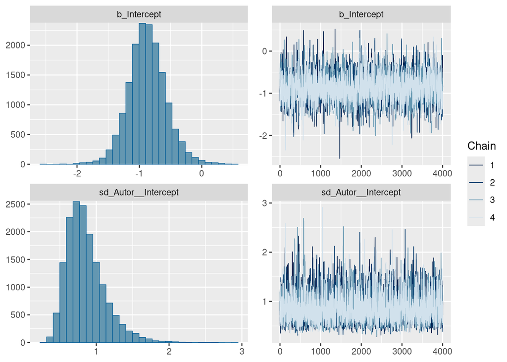

```r
## Model summary
summary(model_prevalence)
##  Family: binomial
##   Links: mu = logit
## Formula: n_EHC_patients | trials(n_patients) ~ 1 + (1 | Autor)
##    Data: data_prevalence (Number of observations: 9)
##   Draws: 4 chains, each with iter = 6000; warmup = 2000; thin = 1;
##          total post-warmup draws = 16000
##
## Multilevel Hyperparameters:
## ~Autor (Number of levels: 9)
##               Estimate Est.Error l-95% CI u-95% CI Rhat Bulk_ESS Tail_ESS
## sd(Intercept)     0.86      0.27     0.47     1.52 1.00     3256     5308
##
## Regression Coefficients:
##           Estimate Est.Error l-95% CI u-95% CI Rhat Bulk_ESS Tail_ESS
## Intercept    -0.87      0.31    -1.46    -0.24 1.00     2791     3766
##
## Draws were sampled using sample(hmc). For each parameter, Bulk_ESS
## and Tail_ESS are effective sample size measures, and Rhat is the potential
## scale reduction factor on split chains (at convergence, Rhat = 1).

## Check convergence and posterior distribution
plot(model_prevalence)
## `stat_bin()` using `bins = 30`. Pick better value with `binwidth`.
```

**Open code**

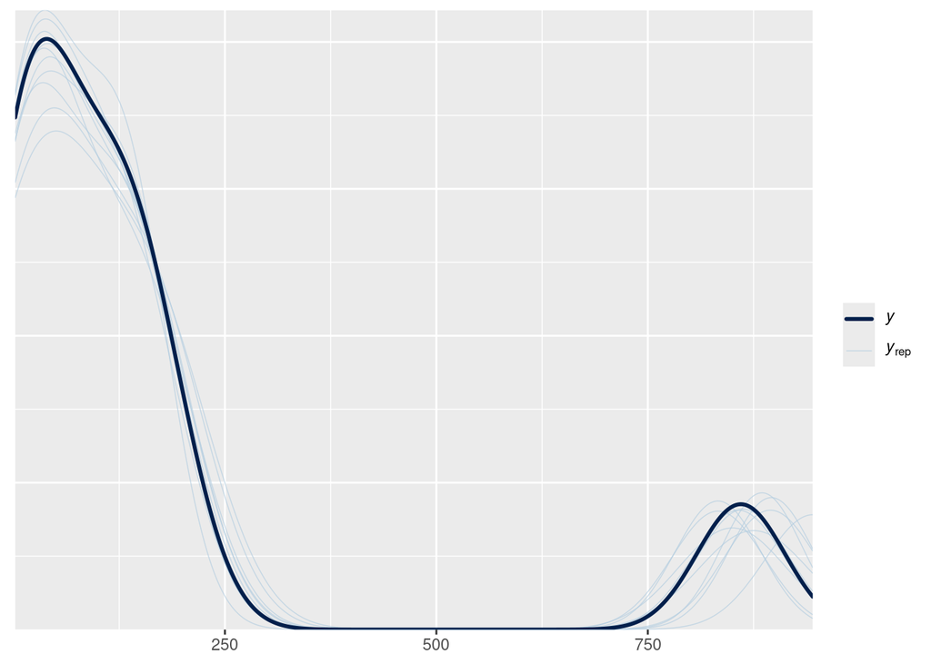

```r
##
pp_check(model_prevalence)
## Using 10 posterior draws for ppc type 'dens_overlay' by default.
```

## 3.5 Heterogeneity between studies

**Open code**

```r
## Tau (SD of random effect on logit scale)
tau <- as_draws_df(model_prevalence)$sd_Autor__Intercept
quantile(tau, c(.025, .5, .975))
##      2.5%       50%     97.5%
## 0.4724618 0.8094670 1.5150022

## Logistic ICC
I2 <- tau^2 / (tau^2 + (pi^2 / 3))
quantile(I2, c(.025, .5, .975))
##       2.5%        50%      97.5%
## 0.06353958 0.16608857 0.41095626

## 95% Predictive interval for a true prevalence in a new study
set.seed(seeding)
d <- as_draws_df(model_prevalence)
eta_new <- rnorm(
  length(d$b_Intercept),
  mean = d$b_Intercept,
  sd = d$sd_Autor__Intercept
)

p_new <- inv_logit(eta_new)
quantile(p_new, c(.025, .5, .975))
##       2.5%        50%      97.5%
## 0.05763875 0.29318526 0.74164831

## Prepare summary info about heterogeneity between studies
fmt_3 <- function(x) sprintf("%.3f", x)
ci_txt <- function(q) paste0(fmt_3(q[2]), " [", fmt_3(q[1]), ", ", fmt_3(q[3]), "]")

tau_ci <- quantile(tau, c(.025, .5, .975))
I2_ci <- quantile(I2, c(.025, .5, .975))
pi_ci <- quantile(p_new, c(.025, .5, .975))

note_tau <- paste0(
  "Between-study SD τ (logit scale): ",
  ci_txt(tau_ci),
  "."
)

note_I2 <- paste0(
  "Logistic ICC (I², latent-scale approximation): ", ci_txt(I2_ci), "."
)

note_pi <- paste0(
  "95% predictive interval for true prevalence in a new study: ",
  ci_txt(pi_ci),
  "."
)
```

Between-study heterogeneity was quantified by $\tau$, defined as the standard deviation of the study-specific random intercepts on the logit scale. Posterior samples of $\tau$ were obtained directly from the fitted hierarchical model, and uncertainty was summarized using the median and the 2.5th and 97.5th percentiles of the posterior distribution.

$I^2$ was calculated as an approximate heterogeneity index on the latent logit scale using the variance of the logistic distribution. Specifically, with between-study heterogeneity $\tau^2$ defined as the variance of the study-specific random intercepts, we computed $I^2 = \frac{\tau^2}{\tau^2 + \pi^2/3}$. This measure represents the proportion of total variance in the linear predictor $\text{logit}(p)$ attributable to between-study heterogeneity and should be interpreted as a latent-scale approximation applicable to binomial models with a logit link.

The between-study variability in prevalence was further summarized using a 95% predictive interval for the true underlying prevalence in a new study. For each posterior draw, a study-specific logit-prevalence was generated as $\eta_{\text{new}}=\mu+u_{\text{new}}$, where $\mu$ denotes the global intercept and $u_{\text{new}}\sim\mathcal N(0,\tau^2)$ represents a random effect for a hypothetical new study. These values were transformed to the prevalence scale using the inverse-logit function, and the predictive interval was defined by the 2.5th and 97.5th percentiles of the resulting distribution.

## 3.6 Tabular results

**Open code**

```r
nd <- data.frame(
  Autor = unique(data_prevalence$Autor),
  n_patients = 1
)

fit <- fitted(
  model_prevalence,
  newdata = nd,
  re_formula = NULL,
  scale = "response",
  summary = TRUE
)

ran_effs <- data.frame(
  Autor = nd$Autor,
  fit[, c("Estimate", "Q2.5", "Q97.5")]
)

pooled_row <- data.frame(
  Autor = "Pooled estimate",
  Estimate = inv_logit(fixef(model_prevalence)["Intercept", "Estimate"]),
  Q2.5 = inv_logit(fixef(model_prevalence)["Intercept", "Q2.5"]),
  Q97.5 = inv_logit(fixef(model_prevalence)["Intercept", "Q97.5"])
)

tr <- rbind(ran_effs, pooled_row) %>%
  dplyr::mutate(
    Prev_empirical = c(data_prevalence$empirical_proportion, p_hat_pooled),
    N = c(data_prevalence$n_patients, sum(data_prevalence$n_patients)),
    N_EHC = c(data_prevalence$n_EHC_patients, sum(data_prevalence$n_EHC_patients))
  ) %>%
  dplyr::rename(
    Prev_model_est = Estimate
  ) %>%
  dplyr::select(
    Autor, N, N_EHC, Prev_empirical, Prev_model_est, everything()
  )

tr %>%
  dplyr::mutate(
    dplyr::across(
      where(is.numeric),
      ~ round(.x, 3)
    )
  ) %>%
  dplyr::mutate(
    `Estimated prevalence [95% CrI]` = paste0(
      Prev_model_est, " [", `Q2.5`, ", ", `Q97.5`, "]"
    )
  ) %>%
  dplyr::rename(
    `Observed prevalence` = `Prev_empirical`
  ) %>%
  dplyr::select(
    Autor, N, `Observed prevalence`, `Estimated prevalence [95% CrI]`
  ) %>%
  kableExtra::kable(
    align = "lrrr",
    caption = 'Observed and model-estimated prevalence of patients with EHC across included studies. For each study, the table reports the sample size (N), the empirical prevalence, and the study-specific posterior median prevalence with 95% credible intervals (CrI) obtained from a Bayesian hierarchical binomial model with a logit link and a random intercept for study. The pooled estimate corresponds to the prevalence in a typical study (random intercept equal to zero). Between-study heterogeneity is summarized by the standard deviation of the random intercepts (τ) on the logit scale and by an approximate latent-scale intraclass correlation coefficient (I²). The 95% predictive interval represents the expected range of the true underlying prevalence in a new study, reflecting between-study heterogeneity rather than sampling uncertainty.'
    ) %>%
  kableExtra::footnote(
    general = c(note_tau, note_I2, note_pi),
    general_title = "",
    threeparttable = TRUE
  ) %>%
    kableExtra::kable_styling(
    bootstrap_options = c("striped", "hover", "condensed"),
    font_size = 12
  )
```

Observed and model-estimated prevalence of patients with EHC across included studies. For each study, the table reports the sample size (N), the empirical prevalence, and the study-specific posterior median prevalence with 95% credible intervals (CrI) obtained from a Bayesian hierarchical binomial model with a logit link and a random intercept for study. The pooled estimate corresponds to the prevalence in a typical study (random intercept equal to zero). Between-study heterogeneity is summarized by the standard deviation of the random intercepts (τ) on the logit scale and by an approximate latent-scale intraclass correlation coefficient (I²). The 95% predictive interval represents the expected range of the true underlying prevalence in a new study, reflecting between-study heterogeneity rather than sampling uncertainty.

| Autor | N | Observed prevalence | Estimated prevalence [95% CrI] |
| --- | --- | --- | --- |
| Eurvilaichit (2001) | 100 | 0.330 | 0.328 [0.242, 0.42] |
| Kim HC (2005) | 3179 | 0.271 | 0.271 [0.255, 0.286] |
| Miyayama S (2005) | 719 | 0.252 | 0.252 [0.222, 0.284] |
| Myiaiama (2010) | 30 | 0.700 | 0.623 [0.449, 0.782] |
| Abdelmaksoud MHK (2011) | 40 | 0.300 | 0.3 [0.179, 0.44] |
| Paul SB (2011) | 85 | 0.094 | 0.117 [0.059, 0.191] |
| Ekajchariya K (2013) | 600 | 0.235 | 0.236 [0.203, 0.271] |
| Li (naive) (2015) | 182 | 0.495 | 0.487 [0.415, 0.558] |
| Ngamsombat C (2018) | 639 | 0.191 | 0.192 [0.163, 0.224] |
| Pooled estimate | 5574 | 0.263 | 0.294 [0.188, 0.441] |

Between-study SD τ (logit scale): 0.809 [0.472, 1.515].  
Logistic ICC (I², latent-scale approximation): 0.166 [0.064, 0.411].  
95% predictive interval for true prevalence in a new study: 0.293 [0.058, 0.742].

## 3.7 Forest plot

**Open code**

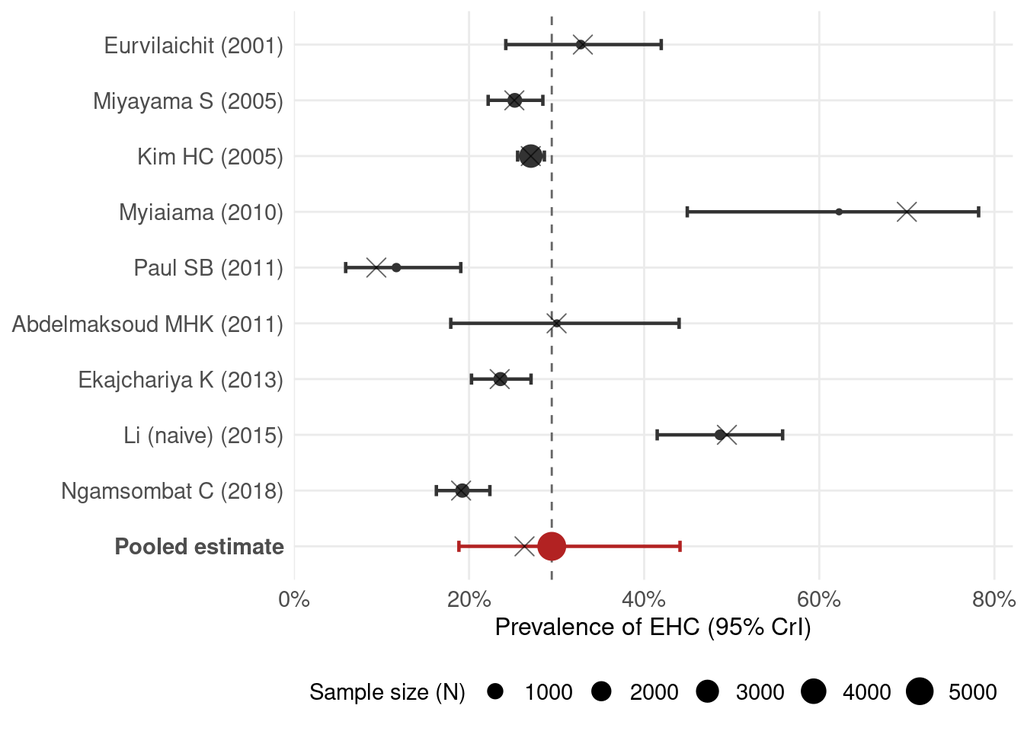

Forest plot of EHC prevalence. Error bars represent 95% credible intervals (CrI) based on a mixed-effects binomial regression model, while crosses (x) represent empirical proportions. The size of the points reflects the study sample size (N).

```r
plot_data <- tr %>%
  dplyr::mutate(
    Autor = factor(
      Autor,
      levels = c(
        "Pooled estimate",
        data_prevalence$Autor[order(
          data_prevalence$Year,
          decreasing = TRUE
        )]
      )
    ),
    is_pooled = dplyr::if_else(
      Autor == "Pooled estimate",
      "Pooled",
      "Study"
    )
  )

forest_plot <- ggplot(
  plot_data,
  aes(
    x = Prev_model_est,
    y = Autor
  )
) +
  geom_vline(
    data = dplyr::filter(
      plot_data,
      Autor == "Pooled estimate"
    ),
    aes(xintercept = Prev_model_est),
    linetype = "dashed",
    color = "grey40"
  ) +
  geom_errorbarh(
    aes(
      xmin = Q2.5,
      xmax = Q97.5,
      color = is_pooled
    ),
    height = 0.2,
    linewidth = 0.8
  ) +
  geom_point(
    aes(
      size = N,
      color = is_pooled
    )
  ) +
  geom_point(
    aes(x = Prev_empirical),
    shape = 4,
    size = 4,
    alpha = 0.6,
    color = "black"
  ) +
  scale_color_manual(
    values = c(
      "Study" = "grey20",
      "Pooled" = "firebrick"
    )
  ) +
  scale_x_continuous(
    labels = scales::percent_format(accuracy = 1),
    limits = c(0, NA),
    expand = expansion(mult = c(0, 0.05))
  ) +
  labs(
    x = "Prevalence of EHC (95% CrI)",
    y = NULL,
    size = "Sample size (N)"
  ) +
  theme_minimal() +
  theme(
    legend.position = "bottom",
    panel.grid.minor = element_blank(),
    axis.title.x = element_text(
      size = 12
    ),
    axis.text.x = element_text(
      size = 11
    ),
    axis.text.y = element_text(
      size = 11,
      face = dplyr::if_else(
        levels(plot_data$Autor) == "Pooled estimate",
        "bold",
        "plain"
      )
    ),
    legend.title = element_text(size = 11),
    legend.text = element_text(size = 11)
  ) +
  guides(color = "none")
## Warning: Vectorized input to `element_text()` is not officially supported.
## ℹ Results may be unexpected or may change in future versions of ggplot2.

forest_plot
```

# 4 Number of ECC per a patient

## 4.1 Set prior

**Open code**

```r
prior_count <- c(
  set_prior(paste0('student_t(3, ', log(count_hat_pooled), ', 100)'), class = "Intercept"),
  prior(exponential(1), class = "sd")
)
```

## 4.2 Fit models

**Open code**

```r
run2(
  name = "model_EHC_count",
  expr = {
    brm(
      n_EHC ~ 1 + offset(log(n_patients)) + (1 | Autor),
      family = poisson(link = "log"),
      data = data_prevalence %>% na.omit(),
      prior = prior_count,
      backend = "cmdstanr",
      seed = seeding,
      cores = 1, chains = 4,
      iter = 6000, warmup = 2000,
      control = list(adapt_delta = 0.95),
      save_pars = save_pars(all = TRUE)
    )
  },
  reuse = TRUE
)

run2(
  name = "model_EHC_count_negbin",
  expr = {
    brm(
      n_EHC ~ 1 + offset(log(n_patients)) + (1 | Autor),
      family = negbinomial(link = "log"),
      data = data_prevalence %>% na.omit(),
      prior = prior_count,
      backend = "cmdstanr",
      seed = seeding,
      cores = 1, chains = 4,
      iter = 6000, warmup = 2000,
      control = list(adapt_delta = 0.99),
      save_pars = save_pars(all = TRUE)
    )
  },
  reuse = TRUE
)

## prior summary
prior_summary(model_EHC_count)
##                                  prior     class      coef group resp dpar
##  student_t(3, -0.587280829721337, 100) Intercept
##                         exponential(1)        sd
##                         exponential(1)        sd           Autor
##                         exponential(1)        sd Intercept Autor
##  nlpar lb ub       source
##                      user
##         0            user
##         0    (vectorized)
##         0    (vectorized)
prior_summary(model_EHC_count_negbin)
##                                  prior     class      coef group resp dpar
##  student_t(3, -0.587280829721337, 100) Intercept
##                         exponential(1)        sd
##                         exponential(1)        sd           Autor
##                         exponential(1)        sd Intercept Autor
##                    inv_gamma(0.4, 0.3)     shape
##  nlpar lb ub       source
##                      user
##         0            user
##         0    (vectorized)
##         0    (vectorized)
##         0         default
```

## 4.3 Compare and check models

**Open code**

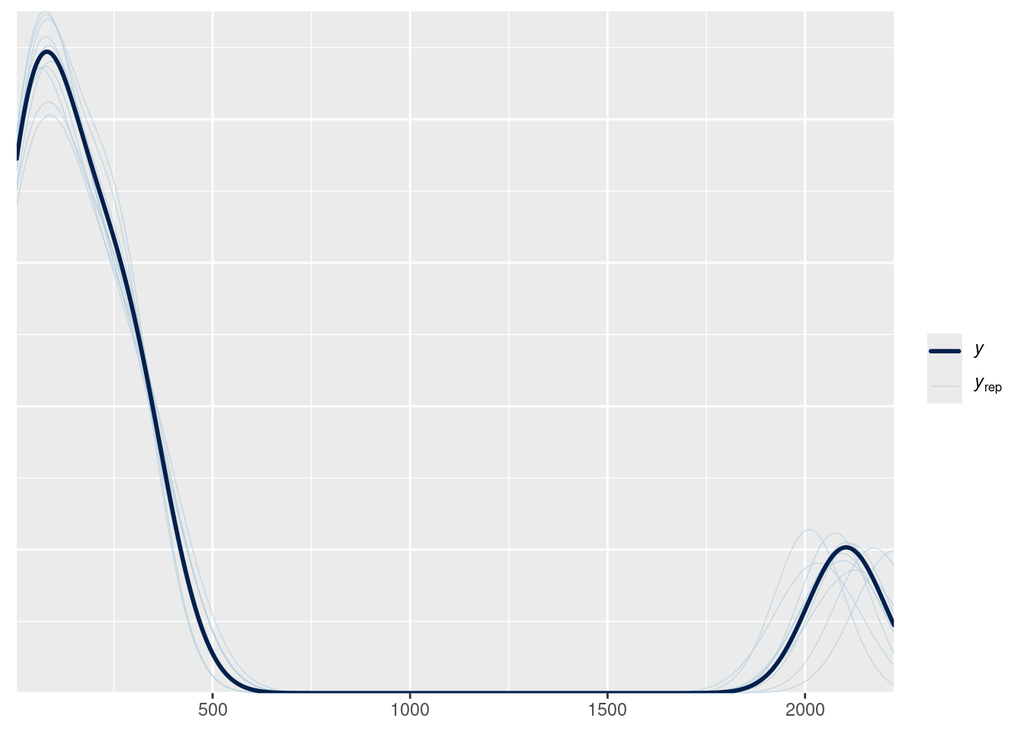

```r
## posterior predictive check
pp_check(model_EHC_count)
## Using 10 posterior draws for ppc type 'dens_overlay' by default.
```

**Open code**

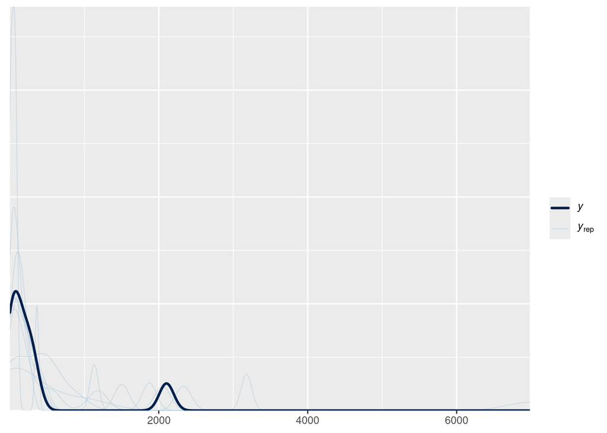

```r
pp_check(model_EHC_count_negbin)
## Using 10 posterior draws for ppc type 'dens_overlay' by default.
```

**Open code**

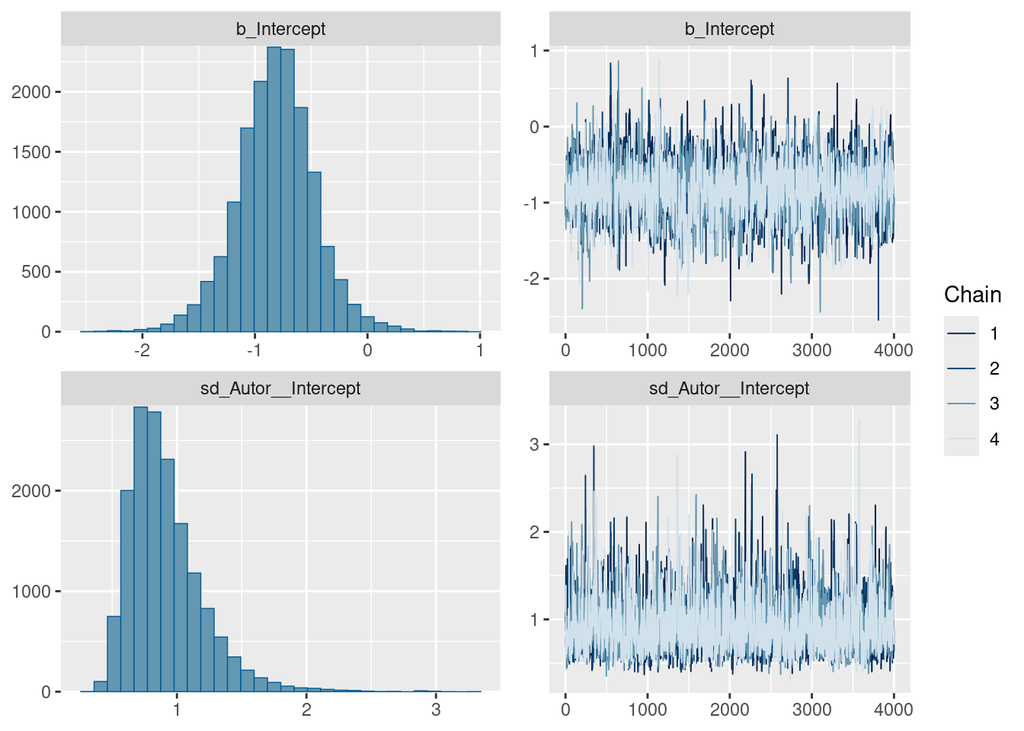

```r
## model comparisons
run2(
  name = "loo_pois",
  loo(model_EHC_count, moment_match = TRUE, reloo = TRUE)
)

run2(
  name = "loo_nb",
  loo(model_EHC_count_negbin, moment_match = TRUE, reloo = TRUE)
)

loo_compare(loo_pois, loo_nb)
##                        elpd_diff se_diff
## model_EHC_count_negbin  0.0       0.0
## model_EHC_count        -0.5       0.3

## Model summary
summary(model_EHC_count)
##  Family: poisson
##   Links: mu = log
## Formula: n_EHC ~ 1 + offset(log(n_patients)) + (1 | Autor)
##    Data: data_prevalence %>% na.omit() (Number of observations: 8)
##   Draws: 4 chains, each with iter = 6000; warmup = 2000; thin = 1;
##          total post-warmup draws = 16000
##
## Multilevel Hyperparameters:
## ~Autor (Number of levels: 8)
##               Estimate Est.Error l-95% CI u-95% CI Rhat Bulk_ESS Tail_ESS
## sd(Intercept)     0.91      0.29     0.53     1.61 1.00     2426     3465
##
## Regression Coefficients:
##           Estimate Est.Error l-95% CI u-95% CI Rhat Bulk_ESS Tail_ESS
## Intercept    -0.82      0.35    -1.52    -0.13 1.00     1751     2433
##
## Draws were sampled using sample(hmc). For each parameter, Bulk_ESS
## and Tail_ESS are effective sample size measures, and Rhat is the potential
## scale reduction factor on split chains (at convergence, Rhat = 1).

## Check convergence and posterior distribution
plot(model_EHC_count)
## `stat_bin()` using `bins = 30`. Pick better value with `binwidth`.
```

## 4.4 Between-study heterogeneity

**Open code**

```r
## Tau (SD of random effect on log scale)
tau <- as_draws_df(model_EHC_count)$sd_Autor__Intercept
quantile(tau, c(.025, .5, .975))
##      2.5%       50%     97.5%
## 0.5252417 0.8571935 1.6135680
lambda <- exp(d$b_Intercept)

## Poisson VPC
set.seed(seeding)
d <- as_draws_df(model_EHC_count)

mu <- d$b_Intercept
tau <- d$sd_Autor__Intercept

S <- 2000
u <- rnorm(length(mu) * S, 0, rep(tau, each = S))
lam <- exp(rep(mu, each = S) + u)

v_between <- tapply(lam, rep(seq_along(mu), each = S), var)
v_total <- tapply(lam + lam^2, rep(seq_along(mu), each = S),
                  mean) - tapply(
                    lam, rep(seq_along(mu), each = S
                             ), mean)^2

VPC <- v_between / v_total
quantile(VPC, c(.025, .5, .975))
##      2.5%       50%     97.5%
## 0.1317292 0.4037078 0.9472268

## 95% Predictive interval for a true count/patient in a new study
set.seed(seeding)
d <- as_draws_df(model_EHC_count)
eta_new <- rnorm(
  length(d$b_Intercept),
  mean = d$b_Intercept,
  sd = d$sd_Autor__Intercept
)

p_new <- exp(eta_new)
quantile(p_new, c(.025, .5, .975))
##       2.5%        50%      97.5%
## 0.05648736 0.44551104 3.55766299

## Prepare summary info about heterogeneity between studies
fmt_3 <- function(x) sprintf("%.3f", x)
ci_txt <- function(q) paste0(fmt_3(q[2]), " [", fmt_3(q[1]), ", ", fmt_3(q[3]), "]")

tau_ci <- quantile(tau, c(.025, .5, .975))
vpc_ci <- quantile(VPC, c(.025, .5, .975))
pi_ci <- quantile(p_new, c(.025, .5, .975))

note_tau <- paste0(
  "Between-study SD τ (log scale): ",
  ci_txt(tau_ci),
  "."
)

note_vpc <- paste0(
  "Poisson VPC: ",
  ci_txt(vpc_ci),
  "."
)

note_pi <- paste0(
  "95% predictive interval for true count per patient in a new study: ",
  ci_txt(pi_ci),
  "."
)
```

## 4.5 Tabular results

**Open code**

```r
nd <- data.frame(
  Autor = unique(data_counts$Autor),
  n_patients = 1
)


fit <- fitted(
  model_EHC_count,
  newdata = nd,
  re_formula = NULL,
  scale = "response",
  summary = TRUE
)

ran_effs <- data.frame(
  Autor = nd$Autor,
  fit[, c("Estimate", "Q2.5", "Q97.5")]
)

pooled_row <- data.frame(
  Autor = "Pooled estimate",
  Estimate = exp(fixef(model_EHC_count)["Intercept", "Estimate"]),
  Q2.5 = exp(fixef(model_EHC_count)["Intercept", "Q2.5"]),
  Q97.5 = exp(fixef(model_EHC_count)["Intercept", "Q97.5"])
)

tr <- rbind(ran_effs, pooled_row) %>%
  dplyr::mutate(
    EHCperPatient_empirical = c(data_counts$n_EHC/data_counts$n_patients,
                                count_hat_pooled),
    N = c(data_counts$n_patients, sum(data_counts$n_patients)),
    N_EHC = c(data_counts$n_EHC_patients, sum(data_counts$n_EHC_patients))
  ) %>%
  dplyr::rename(
    EHCperPatient_ModelEst = Estimate
  ) %>%
  dplyr::select(
    Autor, N, N_EHC, EHCperPatient_empirical, EHCperPatient_ModelEst, everything()
  )

tr %>%
  dplyr::mutate(
    dplyr::across(
      where(is.numeric),
      ~ round(.x, 3)
    )
  ) %>%
  dplyr::mutate(
    `Estimated count/patient [95% CrI]` = paste0(
      EHCperPatient_ModelEst, " [", `Q2.5`, ", ", `Q97.5`, "]"
    )
  ) %>%
  dplyr::rename(
    `Observed EHC count/patient` = `EHCperPatient_empirical`
  ) %>%
  dplyr::select(
    Autor, N, `Observed EHC count/patient`, `Estimated count/patient [95% CrI]`
  ) %>%
  kableExtra::kable(
    align = "lrrr",
    caption = 'Observed and model-estimated counts of EHC per patient across included studies. For each study, the table reports the sample size (N), the empirical mean number of EHC per patient, and the study-specific posterior median rate with 95% credible intervals (CrI) obtained from a Bayesian Poisson mixed-effects model with a log link, an offset for the number of patients, and a random intercept for study. The pooled estimate represents the expected number of EHC per patient in a typical study. Between-study heterogeneity is summarized by the standard deviation of the study-specific random intercepts (τ) on the log scale and by the Poisson variance partition coefficient (VPC). The 95% predictive interval denotes the expected range of the true underlying EHC count per patient in a new study, reflecting between-study heterogeneity rather than sampling variability.'
    ) %>%
  kableExtra::footnote(
    general = c(note_tau, note_vpc, note_pi),
    general_title = "",
    threeparttable = TRUE
  )  %>%
  kableExtra::kable_styling(
    bootstrap_options = c("striped", "hover", "condensed"),
    font_size = 12
  )
```

Observed and model-estimated counts of EHC per patient across included studies. For each study, the table reports the sample size (N), the empirical mean number of EHC per patient, and the study-specific posterior median rate with 95% credible intervals (CrI) obtained from a Bayesian Poisson mixed-effects model with a log link, an offset for the number of patients, and a random intercept for study. The pooled estimate represents the expected number of EHC per patient in a typical study. Between-study heterogeneity is summarized by the standard deviation of the study-specific random intercepts (τ) on the log scale and by the Poisson variance partition coefficient (VPC). The 95% predictive interval denotes the expected range of the true underlying EHC count per patient in a new study, reflecting between-study heterogeneity rather than sampling variability.

| Autor | N | Observed EHC count/patient | Estimated count/patient [95% CrI] |
| --- | --- | --- | --- |
| Eurvilaichit (2001) | 100 | 0.330 | 0.336 [0.234, 0.455] |
| Kim HC (2005) | 3179 | 0.662 | 0.662 [0.634, 0.69] |
| Miyayama S (2005) | 719 | 0.456 | 0.456 [0.407, 0.506] |
| Myiaiama (2010) | 30 | 2.067 | 1.996 [1.522, 2.542] |
| Paul SB (2011) | 85 | 0.094 | 0.118 [0.057, 0.201] |
| Ekajchariya K (2013) | 600 | 0.432 | 0.431 [0.381, 0.486] |
| Li (naive) (2015) | 182 | 0.511 | 0.51 [0.411, 0.618] |
| Ngamsombat C (2018) | 639 | 0.296 | 0.297 [0.256, 0.339] |
| Pooled estimate | 5534 | 0.556 | 0.443 [0.218, 0.88] |

Between-study SD τ (log scale): 0.857 [0.525, 1.614].  
Poisson VPC: 0.404 [0.132, 0.947].  
95% predictive interval for true count per patient in a new study: 0.446 [0.056, 3.558].

## 4.6 Forest plot

**Open code**

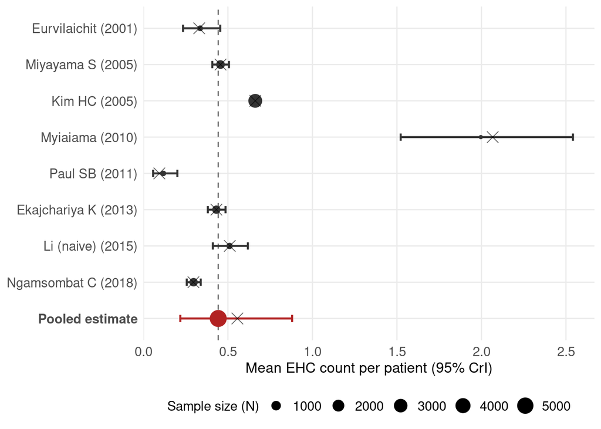

Forest plot of mean EHC count per patient. Crosses (x) represent empirical means, and error bars represent 95% credible intervals based on a mixed-effect Poisson regression model

```r
plot_data_counts <- tr %>%
  dplyr::mutate(
    Autor = factor(
      Autor,
      levels = c(
        "Pooled estimate",
        data_prevalence$Autor[order(
          data_prevalence$Year,
          decreasing = TRUE
        )]
      )
    ),
    is_pooled = dplyr::if_else(
      Autor == "Pooled estimate",
      "Pooled",
      "Study"
    ),
    is_bold = dplyr::if_else(
      Autor == "Pooled estimate",
      "bold",
      "plain"
    )
  )

forest_plot_counts <- ggplot(
  plot_data_counts,
  aes(
    x = EHCperPatient_ModelEst,
    y = Autor
  )
) +
  geom_vline(
    data = dplyr::filter(
      plot_data_counts,
      is_pooled == "Pooled"
    ),
    aes(xintercept = EHCperPatient_ModelEst),
    linetype = "dashed",
    color = "grey40"
  ) +
  geom_errorbarh(
    aes(
      xmin = Q2.5,
      xmax = Q97.5,
      color = is_pooled
    ),
    height = 0.2,
    linewidth = 0.8
  ) +
  geom_point(
    aes(
      size = N,
      color = is_pooled
    )
  ) +
  geom_point(
    aes(x = EHCperPatient_empirical),
    shape = 4,
    size = 4,
    alpha = 0.6,
    color = "black"
  ) +
  scale_color_manual(
    values = c(
      "Study" = "grey20",
      "Pooled" = "firebrick"
    )
  ) +
  scale_x_continuous(
    labels = scales::number_format(accuracy = 0.1),
    limits = c(0, NA),
    expand = expansion(mult = c(0, 0.05))
  ) +
  labs(
    x = "Mean EHC count per patient (95% CrI)",
    y = NULL,
    size = "Sample size (N)"
  ) +
  theme_minimal() +
  theme(
    legend.position = "bottom",
    panel.grid.minor = element_blank(),
    axis.title.x = element_text(
      size = 12
    ),
    axis.text.x = element_text(
      size = 11
    ),
    axis.text.y = element_text(
      size = 11,
      face = dplyr::if_else(
        levels(plot_data$Autor) == "Pooled estimate",
        "bold",
        "plain"
      )
    ),
    legend.title = element_text(size = 11),
    legend.text = element_text(size = 11)
  ) +
  guides(color = "none")
## Warning: Vectorized input to `element_text()` is not officially supported.
## ℹ Results may be unexpected or may change in future versions of ggplot2.

forest_plot_counts
```

# 5 Proportion of vessel categories

## 5.1 Show data

**Open code**

```r
kableExtra::kable(
  data_mult_raw %>%
    dplyr::select(-n_EHC, -Year) %>%
    dplyr::rename('n_EHC' = n_EHC2)
  )
```

| Autor | n_EHC | Inferior_phrenic_artery | Coeliac_trunk_branches | SMA_branches | Renal_adrenal_arteries | IMA | Abdominal_wall_artery |
| --- | --- | --- | --- | --- | --- | --- | --- |
| Eurvalicht (2001) | 33 | 13 | 10 | 6 | 1 | 2 | 1 |
| Kim HC (2005) | 2104 | 1104 | 464 | 48 | 258 | 97 | 133 |
| Miyayama S (2005) | 328 | 167 | 82 | 5 | 41 | 16 | 17 |
| Wang YL (2005) | 39 | 15 | 6 | 9 | 4 | 2 | 3 |
| Myiaiama (2010) | 62 | 20 | 20 | 3 | 11 | 3 | 5 |
| Paul SB (2011) | 8 | 1 | 4 | 1 | 0 | 1 | 1 |
| Ekajchariya K (2013) | 259 | 96 | 81 | 23 | 22 | 7 | 30 |
| Li (2015) | 93 | 90 | 3 | 0 | 0 | 0 | 0 |
| Ngamsombat C (2018) | 189 | 76 | 83 | 10 | 12 | 0 | 8 |

## 5.2 Set prior

**Open code**

```r
y_matrix_old <- data_mult_raw %>%
  dplyr::select(
    Inferior_phrenic_artery,
    Coeliac_trunk_branches,
    SMA_branches,
    Renal_adrenal_arteries,
    IMA,
    Abdominal_wall_artery
  ) %>%
  as.matrix()

col_sums_old <- colSums(y_matrix_old)
col_names_old <- colnames(y_matrix_old)

ref_count_old <- col_sums_old["Inferior_phrenic_artery"]

other_counts_old <- col_sums_old[names(col_sums_old) != "Inferior_phrenic_artery"]
other_names_old <- names(other_counts_old)

calc_multinom_logit <- function(target_count, reference_count) {
  log((target_count + 0.01) / (reference_count + 0.01))
}

prior_intercepts_old <- purrr::map(
  seq_along(other_counts_old),
  function(i) {
    target_val <- other_counts_old[i]
    target_name <- other_names_old[i]

    l_val <- calc_multinom_logit(target_val, ref_count_old)

    dpar_name <- paste0("mu", gsub("[_.]", "", target_name))

    brms::set_prior(
      paste0("student_t(3, ", round(l_val, 3), ", 10)"),
      class = "Intercept",
      dpar = dpar_name
    )
  }
)

prior_multinomial <- c(
  do.call(c, prior_intercepts_old),
  brms::set_prior(
    "exponential(1)",
    class = "sd",
    dpar = paste0("mu", gsub("[_.]", "", other_names_old))
  )
)
```

## 5.3 Fit model

**Open code**

```r
data_model <- data_mult_raw %>%
  dplyr::select(
    Autor, n_EHC2,
    Inferior_phrenic_artery,
    Coeliac_trunk_branches,
    SMA_branches,
    Renal_adrenal_arteries,
    IMA,
    Abdominal_wall_artery
  ) %>%
  dplyr::mutate(Y = as.matrix(across(c(
    Inferior_phrenic_artery,
    Coeliac_trunk_branches,
    SMA_branches,
    Renal_adrenal_arteries,
    IMA,
    Abdominal_wall_artery
  ))))

run2(
  name = "model_vessels_multinom",
  expr = {
    brm(
      Y | trials(n_EHC2) ~ 1 + (1 | Autor),
  family = multinomial(link = "logit", refcat = "Inferior_phrenic_artery"),
  data = data_model,
  prior = prior_multinomial,
  backend = "cmdstanr",
  seed = seeding,
  cores = 1, chains = 4,
  iter = 6000, warmup = 2000,
  control = list(adapt_delta = 0.95)
)
  },
  reuse = TRUE
)

## check prior of the model
prior_summary(model_vessels_multinom)
##                     prior     class      coef group resp                   dpar
##  student_t(3, -2.078, 10) Intercept                       muAbdominalwallartery
##  student_t(3, -0.742, 10) Intercept                      muCoeliactrunkbranches
##  student_t(3, -2.514, 10) Intercept                                       muIMA
##  student_t(3, -1.511, 10) Intercept                      muRenaladrenalarteries
##  student_t(3, -2.712, 10) Intercept                               muSMAbranches
##            exponential(1)        sd                       muAbdominalwallartery
##            exponential(1)        sd                      muCoeliactrunkbranches
##            exponential(1)        sd                                       muIMA
##            exponential(1)        sd                      muRenaladrenalarteries
##            exponential(1)        sd                               muSMAbranches
##            exponential(1)        sd           Autor       muAbdominalwallartery
##            exponential(1)        sd Intercept Autor       muAbdominalwallartery
##            exponential(1)        sd           Autor      muCoeliactrunkbranches
##            exponential(1)        sd Intercept Autor      muCoeliactrunkbranches
##            exponential(1)        sd           Autor                       muIMA
##            exponential(1)        sd Intercept Autor                       muIMA
##            exponential(1)        sd           Autor      muRenaladrenalarteries
##            exponential(1)        sd Intercept Autor      muRenaladrenalarteries
##            exponential(1)        sd           Autor               muSMAbranches
##            exponential(1)        sd Intercept Autor               muSMAbranches
##  nlpar lb ub       source
##                      user
##                      user
##                      user
##                      user
##                      user
##         0            user
##         0            user
##         0            user
##         0            user
##         0            user
##         0    (vectorized)
##         0    (vectorized)
##         0    (vectorized)
##         0    (vectorized)
##         0    (vectorized)
##         0    (vectorized)
##         0    (vectorized)
##         0    (vectorized)
##         0    (vectorized)
##         0    (vectorized)
```

## 5.4 Check model

**Open code**

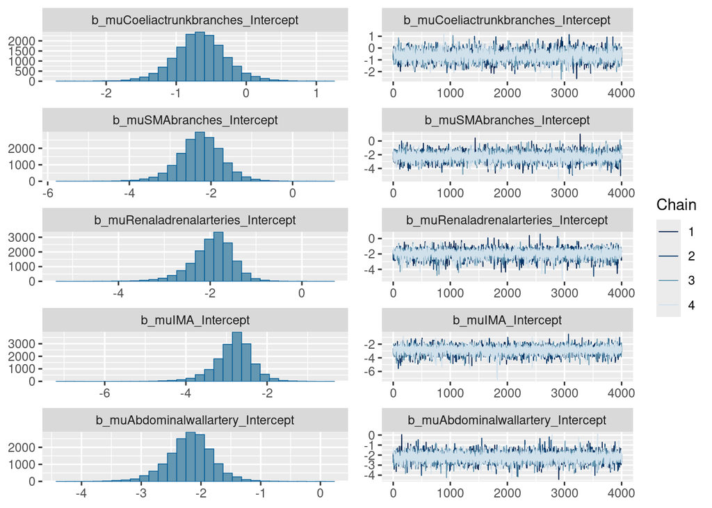

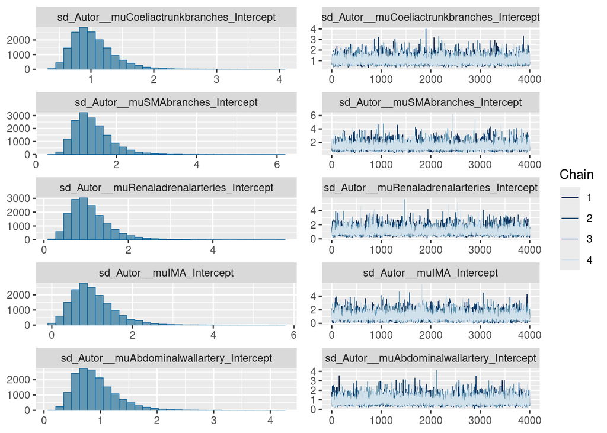

```r
## model summary
summary(model_vessels_multinom)
## Warning: There were 5 divergent transitions after warmup. Increasing
## adapt_delta above 0.95 may help. See
## http://mc-stan.org/misc/warnings.html#divergent-transitions-after-warmup
##  Family: multinomial
##   Links: muCoeliactrunkbranches = logit; muSMAbranches = logit; muRenaladrenalarteries = logit; muIMA = logit; muAbdominalwallartery = logit
## Formula: Y | trials(n_EHC2) ~ 1 + (1 | Autor)
##    Data: data_model (Number of observations: 9)
##   Draws: 4 chains, each with iter = 6000; warmup = 2000; thin = 1;
##          total post-warmup draws = 16000
##
## Multilevel Hyperparameters:
## ~Autor (Number of levels: 9)
##                                      Estimate Est.Error l-95% CI u-95% CI Rhat
## sd(muCoeliactrunkbranches_Intercept)     1.03      0.34     0.55     1.84 1.00
## sd(muSMAbranches_Intercept)              1.41      0.47     0.75     2.54 1.00
## sd(muRenaladrenalarteries_Intercept)     1.09      0.48     0.42     2.28 1.00
## sd(muIMA_Intercept)                      1.02      0.54     0.22     2.28 1.00
## sd(muAbdominalwallartery_Intercept)      0.91      0.38     0.38     1.85 1.00
##                                      Bulk_ESS Tail_ESS
## sd(muCoeliactrunkbranches_Intercept)     5528     8952
## sd(muSMAbranches_Intercept)              5575     9374
## sd(muRenaladrenalarteries_Intercept)     4567     8073
## sd(muIMA_Intercept)                      4009     4902
## sd(muAbdominalwallartery_Intercept)      5867     8927
##
## Regression Coefficients:
##                                  Estimate Est.Error l-95% CI u-95% CI Rhat
## muCoeliactrunkbranches_Intercept    -0.65      0.38    -1.41     0.11 1.00
## muSMAbranches_Intercept             -2.26      0.55    -3.40    -1.19 1.00
## muRenaladrenalarteries_Intercept    -1.95      0.46    -3.00    -1.16 1.00
## muIMA_Intercept                     -2.83      0.47    -3.88    -1.98 1.00
## muAbdominalwallartery_Intercept     -2.18      0.39    -2.99    -1.44 1.00
##                                  Bulk_ESS Tail_ESS
## muCoeliactrunkbranches_Intercept     4174     6275
## muSMAbranches_Intercept              4538     6518
## muRenaladrenalarteries_Intercept     4425     6089
## muIMA_Intercept                      6258     7748
## muAbdominalwallartery_Intercept      5648     7224
##
## Draws were sampled using sample(hmc). For each parameter, Bulk_ESS
## and Tail_ESS are effective sample size measures, and Rhat is the potential
## scale reduction factor on split chains (at convergence, Rhat = 1).

## check convergence
plot(model_vessels_multinom)
## `stat_bin()` using `bins = 30`. Pick better value with `binwidth`.
```

## 5.5 Between study heterogeneity

**Open code**

```r
vessels_all <- c(
  "Inferior_phrenic_artery",
  "Coeliac_trunk_branches",
  "SMA_branches",
  "Renal_adrenal_arteries",
  "IMA",
  "Abdominal_wall_artery"
)

dpars_raw <- c(
  "muCoeliactrunkbranches",
  "muSMAbranches",
  "muRenaladrenalarteries",
  "muIMA",
  "muAbdominalwallartery"
)

draws <- brms::as_draws_df(model_vessels_multinom)

set.seed(seeding)

# 1. Simulace p_new_probs
p_new_probs <- draws %>%
  tibble::as_tibble() %>%
  dplyr::mutate(
    dplyr::across(
      dplyr::all_of(paste0("b_", dpars_raw, "_Intercept")),
      ~ . + rnorm(
        n(),
        0,
        draws[[gsub("b_", "sd_Autor__", dplyr::cur_column())]]
      ),
      .names = "sim_{.col}"
    )
  ) %>%
  dplyr::mutate(
    dplyr::across(
      dplyr::starts_with("sim_b_mu"),
      ~ exp(.),
      .names = "exp_{.col}"
    )
  ) %>%
  dplyr::mutate(
    exp_sum = 1 + rowSums(
      dplyr::select(
        .,
        dplyr::starts_with("exp_sim_b_mu")
      )
    )
  ) %>%
  dplyr::mutate(
    Inferior_phrenic_artery = 1 / exp_sum
  ) %>%
  dplyr::mutate(
    dplyr::across(
      dplyr::starts_with("exp_sim_b_mu"),
      ~ . / exp_sum,
      .names = "{.col}_prob"
    )
  )

names(p_new_probs) <- names(p_new_probs) %>%
  gsub("exp_sim_b_mu", "", .) %>%
  gsub("_Intercept_prob", "", .) %>%
  gsub("Coeliactrunkbranches", "Coeliac_trunk_branches", .) %>%
  gsub("SMAbranches", "SMA_branches", .) %>%
  gsub("Renaladrenalarteries", "Renal_adrenal_arteries", .) %>%
  gsub("Abdominalwallartery", "Abdominal_wall_artery", .)

p_new_probs <- p_new_probs %>%
  dplyr::select(dplyr::all_of(vessels_all))

pooled_probs <- draws %>%
  tibble::as_tibble() %>%
  dplyr::mutate(
    dplyr::across(
      dplyr::all_of(paste0("b_", dpars_raw, "_Intercept")),
      ~ exp(.),
      .names = "exp_{.col}"
    )
  ) %>%
  dplyr::mutate(
    sum_exp = 1 + rowSums(dplyr::select(., dplyr::starts_with("exp_b_mu")))
  ) %>%
  dplyr::mutate(
    Inferior_phrenic_artery = 1 / sum_exp,
    Coeliac_trunk_branches = exp_b_muCoeliactrunkbranches_Intercept / sum_exp,
    SMA_branches = exp_b_muSMAbranches_Intercept / sum_exp,
    Renal_adrenal_arteries = exp_b_muRenaladrenalarteries_Intercept / sum_exp,
    IMA = exp_b_muIMA_Intercept / sum_exp,
    Abdominal_wall_artery = exp_b_muAbdominalwallartery_Intercept / sum_exp
  ) %>%
  dplyr::select(dplyr::all_of(vessels_all))


tau_samples_list <- purrr::map(
  dpars_raw,
  ~ draws[[paste0("sd_Autor__", .x, "_Intercept")]]
)

names(tau_samples_list) <- dpars_raw %>%
  gsub("mu", "", .) %>%
  gsub("Coeliactrunkbranches", "Coeliac_trunk_branches", .) %>%
  gsub("SMAbranches", "SMA_branches", .) %>%
  gsub("Renaladrenalarteries", "Renal_adrenal_arteries", .) %>%
  gsub("Abdominalwallartery", "Abdominal_wall_artery", .)

tau_quantiles <- purrr::map(
  tau_samples_list,
  ~ quantile(.x, c(0.025, 0.5, 0.975))
)

i2_quantiles <- purrr::map(
  tau_samples_list,
  ~ quantile(.x^2 / (.x^2 + (pi^2 / 3)), c(0.025, 0.5, 0.975))
)

p_new_list <- purrr::map(
  p_new_probs,
  ~ quantile(.x, c(0.025, 0.5, 0.975))
)

final_heterogeneity_table <- tibble::tibble(
  vessel = vessels_all
) %>%
  dplyr::mutate(
    tau_res = purrr::map_chr(
      vessel,
      function(v) {
        if (v %in% names(tau_quantiles)) {
          ci_txt(tau_quantiles[[v]])
        } else {
          NA_character_
        }
      }
    ),
    i2_res = purrr::map_chr(
      vessel,
      function(v) {
        if (v %in% names(i2_quantiles)) {
          ci_txt(i2_quantiles[[v]])
        } else {
          NA_character_
        }
      }
    ),
    pi_res = purrr::map_chr(
      vessel,
      function(v) {
        ci_txt(p_new_list[[v]])
      }
    )
  )
```

## 5.6 Tabular results of model

**Open code**

```r
study_fitted <- fitted(
  model_vessels_multinom,
  newdata = data.frame(Autor = unique(data_mult_raw$Autor), n_EHC2 = 1),
  re_formula = NULL,
  summary = TRUE
)

model_categories <- dimnames(study_fitted)[[3]]

study_estimates_final <- purrr::map_dfc(
  seq_along(model_categories),
  function(i) {
    mat <- study_fitted[, , i]

    res <- tibble::tibble(
      !!model_categories[i] := purrr::map_chr(
        seq_len(nrow(mat)),
        function(row_idx) {
          ci_txt(mat[row_idx, c("Q2.5", "Estimate", "Q97.5")])
        }
      )
    )
    return(res)
  }
) %>%
  dplyr::mutate(
    Autor = unique(data_mult_raw$Autor),
    .before = 1
  )

pooled_estimates_wide <- purrr::map_dfc(
  model_categories,
  function(v) {
    clean_v <- gsub("P\\(Y = |\\)", "", v) %>%
      gsub("_", "", .)

    prob_col <- names(pooled_probs)[
      gsub("_", "", names(pooled_probs)) == clean_v
    ]

    if (length(prob_col) == 0) {
       prob_col <- names(pooled_probs)[match(v, names(pooled_probs))]
    }

    q <- quantile(
      pooled_probs[[prob_col]],
      c(0.025, 0.5, 0.975)
    )

    tibble::tibble(
      !!v := ci_txt(q)
    )
  }
) %>%
  dplyr::mutate(
    Autor = "Pooled estimate",
    .before = 1
  )

final_table <- dplyr::bind_rows(
  study_estimates_final,
  pooled_estimates_wide
)

clean_colnames <- names(final_table) %>%
  gsub("P\\(Y = ", "", .) %>%
  gsub("\\)", "", .) %>%
  gsub("_", " ", .)


final_table %>%
  kableExtra::kable(
    col.names = clean_colnames,
    align = c("l", rep("r", length(model_categories))),
    caption = "Model-estimated proportions [95% CrI] of arterial sources for EHC, based on a Bayesian hierarchical multinomial model with a logit link and a random intercept for study"
  ) %>%
  kableExtra::kable_styling(
    bootstrap_options = c("striped", "hover", "condensed"),
    font_size = 12
  ) %>%
  kableExtra::footnote(
    general = c(
      "Heterogeneity summary:",
      purrr::map_chr(
        seq_len(nrow(final_heterogeneity_table)),
        function(i) {
          row <- final_heterogeneity_table[i, ]
          paste0(
            gsub("_", " ", row$vessel), ": τ=",
            ifelse(is.na(row$tau_res), "-", row$tau_res),
            "; I²=", ifelse(is.na(row$i2_res), "-", row$i2_res),
            "; PI=", row$pi_res
          )
        }
      )
    ),
    general_title = "",
    threeparttable = TRUE
  )
```

Model-estimated proportions [95% CrI] of arterial sources for EHC, based on a Bayesian hierarchical multinomial model with a logit link and a random intercept for study

| Autor | Inferior phrenic artery | Coeliac trunk branches | SMA branches | Renal adrenal arteries | IMA | Abdominal wall artery |
| --- | --- | --- | --- | --- | --- | --- |
| Eurvalicht (2001) | 0.416 [0.279, 0.556] | 0.293 [0.163, 0.446] | 0.159 [0.062, 0.292] | 0.046 [0.007, 0.118] | 0.045 [0.010, 0.120] | 0.042 [0.008, 0.104] |
| Kim HC (2005) | 0.525 [0.504, 0.547] | 0.221 [0.203, 0.239] | 0.023 [0.017, 0.030] | 0.122 [0.109, 0.137] | 0.046 [0.037, 0.055] | 0.063 [0.053, 0.074] |
| Miyayama S (2005) | 0.510 [0.458, 0.562] | 0.250 [0.206, 0.297] | 0.018 [0.006, 0.034] | 0.123 [0.090, 0.160] | 0.047 [0.028, 0.071] | 0.053 [0.032, 0.079] |
| Wang YL (2005) | 0.427 [0.300, 0.557] | 0.164 [0.075, 0.282] | 0.206 [0.099, 0.342] | 0.094 [0.032, 0.187] | 0.041 [0.009, 0.106] | 0.068 [0.021, 0.148] |
| Myiaiama (2010) | 0.373 [0.269, 0.482] | 0.313 [0.209, 0.426] | 0.048 [0.013, 0.106] | 0.158 [0.082, 0.253] | 0.039 [0.012, 0.093] | 0.070 [0.027, 0.136] |
| Paul SB (2011) | 0.347 [0.150, 0.561] | 0.397 [0.157, 0.689] | 0.087 [0.008, 0.295] | 0.047 [0.002, 0.158] | 0.052 [0.006, 0.202] | 0.070 [0.010, 0.223] |
| Ekajchariya K (2013) | 0.383 [0.327, 0.441] | 0.311 [0.256, 0.368] | 0.087 [0.057, 0.123] | 0.084 [0.053, 0.119] | 0.027 [0.012, 0.047] | 0.109 [0.075, 0.151] |
| Li (2015) | 0.859 [0.776, 0.926] | 0.059 [0.019, 0.118] | 0.014 [0.001, 0.044] | 0.024 [0.001, 0.071] | 0.019 [0.001, 0.057] | 0.025 [0.002, 0.067] |
| Ngamsombat C (2018) | 0.397 [0.331, 0.465] | 0.434 [0.366, 0.505] | 0.052 [0.026, 0.086] | 0.064 [0.035, 0.100] | 0.009 [0.000, 0.027] | 0.043 [0.021, 0.074] |
| Pooled estimate | 0.505 [0.376, 0.610] | 0.263 [0.142, 0.437] | 0.053 [0.017, 0.139] | 0.074 [0.026, 0.149] | 0.031 [0.010, 0.069] | 0.057 [0.025, 0.114] |

Heterogeneity summary:  
Inferior phrenic artery: τ=-; I²=-; PI=0.426 [0.091, 0.704]  
Coeliac trunk branches: τ=0.976 [0.552, 1.841]; I²=0.224 [0.085, 0.507]; PI=0.227 [0.020, 0.770]  
SMA branches: τ=1.328 [0.753, 2.540]; I²=0.349 [0.147, 0.662]; PI=0.045 [0.001, 0.539]  
Renal adrenal arteries: τ=0.997 [0.419, 2.278]; I²=0.232 [0.051, 0.612]; PI=0.061 [0.003, 0.442]  
IMA: τ=0.930 [0.219, 2.283]; I²=0.208 [0.014, 0.613]; PI=0.025 [0.001, 0.228]  
Abdominal wall artery: τ=0.843 [0.378, 1.847]; I²=0.178 [0.042, 0.509]; PI=0.047 [0.003, 0.313]

## 5.7 Empirical proportions

**Open code**

```r
empirical_data <- data_mult_raw %>%
  dplyr::select(
    Autor,
    n_EHC2,
    dplyr::all_of(vessels_all)
  ) %>%
  dplyr::mutate(
    dplyr::across(
      dplyr::all_of(vessels_all),
      ~ .x / n_EHC2
    )
  )

total_row <- data_mult_raw %>%
  dplyr::summarise(
    Autor = "Total / Overall",
    n_EHC2 = sum(n_EHC2),
    dplyr::across(
      dplyr::all_of(vessels_all),
      ~ sum(.x) / sum(n_EHC2)
    )
  )

empirical_final <- dplyr::bind_rows(
  empirical_data,
  total_row
)

clean_empirical_colnames <- names(empirical_final) %>%
  gsub("_", " ", .) %>%
  gsub("n EHC2", "Count of EHCs", .)


empirical_final %>%
  kableExtra::kable(
    col.names = clean_empirical_colnames,
    digits = 3,
    align = c("l", "c", rep("r", length(vessels_all))),
    caption = "Empirical proportions of arterial sources for EHC across included studies."
  ) %>%
  kableExtra::kable_styling(
    bootstrap_options = c(
      "striped",
      "hover",
      "condensed"
    ),
    font_size = 12
  ) %>%
  kableExtra::row_spec(
    nrow(empirical_final),
    bold = TRUE,
    extra_css = "border-top: 2px solid black;"
  )
```

Empirical proportions of arterial sources for EHC across included studies.

| Autor | Count of EHCs | Inferior phrenic artery | Coeliac trunk branches | SMA branches | Renal adrenal arteries | IMA | Abdominal wall artery |
| --- | --- | --- | --- | --- | --- | --- | --- |
| Eurvalicht (2001) | 33 | 0.394 | 0.303 | 0.182 | 0.030 | 0.061 | 0.030 |
| Kim HC (2005) | 2104 | 0.525 | 0.221 | 0.023 | 0.123 | 0.046 | 0.063 |
| Miyayama S (2005) | 328 | 0.509 | 0.250 | 0.015 | 0.125 | 0.049 | 0.052 |
| Wang YL (2005) | 39 | 0.385 | 0.154 | 0.231 | 0.103 | 0.051 | 0.077 |
| Myiaiama (2010) | 62 | 0.323 | 0.323 | 0.048 | 0.177 | 0.048 | 0.081 |
| Paul SB (2011) | 8 | 0.125 | 0.500 | 0.125 | 0.000 | 0.125 | 0.125 |
| Ekajchariya K (2013) | 259 | 0.371 | 0.313 | 0.089 | 0.085 | 0.027 | 0.116 |
| Li (2015) | 93 | 0.968 | 0.032 | 0.000 | 0.000 | 0.000 | 0.000 |
| Ngamsombat C (2018) | 189 | 0.402 | 0.439 | 0.053 | 0.063 | 0.000 | 0.042 |
| Total / Overall | 3115 | 0.508 | 0.242 | 0.034 | 0.112 | 0.041 | 0.064 |

# 6 Proportion of specific vessels

## 6.1 Show data

**Open code**

```r
kableExtra::kable(
  data_mult_spec %>%
    dplyr::select(-n_EHC, -Year) %>%
    dplyr::rename('n_EHC' = n_EHC2)
  )
```

| Autor | n_EHC | Inferior_phrenic_artery | Coeliac_trunk | Left_gastric_artery | Gastric_artery | Periportal_collateral_vessels | Splenic_artery | Left_gastroepiploic | GDA | Right_gastric | Right_gastroepiploic | Cystic | Bile_duct_artery | Pancreatoduodenal_artery | Dorsal_pancreatic | Omental_arteries | SMA_or_branch_SMA | Right_or_middle_colic_artery | Right_renal_or_capsular | Adrenal_arteries | IMA | Intercostal_arteries_plus_subcostal | Lumbar |
| --- | --- | --- | --- | --- | --- | --- | --- | --- | --- | --- | --- | --- | --- | --- | --- | --- | --- | --- | --- | --- | --- | --- | --- |
| Eurvalicht (2001) | 33 | 13 | 0 | 1 | 0 | 7 | 0 | 0 | 0 | 0 | 0 | 0 | 0 | 1 | 0 | 1 | 5 | 1 | 1 | 0 | 2 | 1 | 0 |
| Kim HC (2005) | 2104 | 1104 | 0 | 46 | 0 | 0 | 0 | 0 | 0 | 23 | 0 | 89 | 0 | 0 | 0 | 306 | 48 | 0 | 70 | 188 | 97 | 128 | 5 |
| Miyayama S (2005) | 328 | 167 | 0 | 7 | 0 | 0 | 0 | 0 | 0 | 5 | 0 | 43 | 4 | 0 | 0 | 23 | 0 | 5 | 21 | 20 | 16 | 14 | 3 |
| Wang YL (2005) | 39 | 15 | 0 | 5 | 0 | 0 | 0 | 0 | 0 | 0 | 0 | 0 | 0 | 0 | 0 | 1 | 9 | 0 | 4 | 0 | 2 | 3 | 0 |
| Myiaiama (2010) | 62 | 20 | 0 | 4 | 0 | 0 | 0 | 1 | 0 | 1 | 0 | 6 | 2 | 0 | 2 | 4 | 0 | 3 | 6 | 5 | 3 | 4 | 1 |
| Paul SB (2011) | 8 | 1 | 0 | 0 | 0 | 0 | 0 | 0 | 3 | 0 | 0 | 0 | 0 | 0 | 0 | 1 | 1 | 0 | 0 | 0 | 1 | 1 | 0 |
| Ekajchariya K (2013) | 259 | 96 | 1 | 10 | 0 | 0 | 4 | 1 | 23 | 4 | 28 | 8 | 0 | 2 | 0 | 0 | 23 | 0 | 6 | 16 | 7 | 29 | 1 |
| Li (2015) | 93 | 90 | 0 | 3 | 0 | 0 | 0 | 0 | 0 | 0 | 0 | 0 | 0 | 0 | 0 | 0 | 0 | 0 | 0 | 0 | 0 | 0 | 0 |
| Ngamsombat C (2018) | 189 | 76 | 0 | 18 | 0 | 0 | 0 | 0 | 0 | 2 | 0 | 5 | 0 | 0 | 0 | 58 | 0 | 10 | 6 | 6 | 0 | 8 | 0 |

**Open code**

```r
skimr::skim(data_mult_spec)
```

Data summary

| Name | data_mult_spec |
| --- | --- |
| Number of rows | 9 |
| Number of columns | 26 |
| _______________________ |  |
| Column type frequency: |  |
| character | 1 |
| numeric | 25 |
| ________________________ |  |
| Group variables | None |

**Variable type: character**

| skim_variable | n_missing | complete_rate | min | max | empty | n_unique | whitespace |
| --- | --- | --- | --- | --- | --- | --- | --- |
| Autor | 0 | 1 | 9 | 20 | 0 | 9 | 0 |

**Variable type: numeric**

| skim_variable | n_missing | complete_rate | mean | sd | p0 | p25 | p50 | p75 | p100 | hist |
| --- | --- | --- | --- | --- | --- | --- | --- | --- | --- | --- |
| Year | 0 | 1 | 2009.22 | 5.59 | 2001 | 2005 | 2010 | 2013 | 2018 | ▂▇▅▂▅ |
| n_EHC | 0 | 1 | 362.22 | 661.64 | 8 | 62 | 178 | 259 | 2104 | ▇▁▁▁▁ |
| n_EHC2 | 0 | 1 | 346.11 | 668.42 | 8 | 39 | 93 | 259 | 2104 | ▇▁▁▁▁ |
| Inferior_phrenic_artery | 0 | 1 | 175.78 | 352.23 | 1 | 15 | 76 | 96 | 1104 | ▇▁▁▁▁ |
| Coeliac_trunk | 0 | 1 | 0.11 | 0.33 | 0 | 0 | 0 | 0 | 1 | ▇▁▁▁▁ |
| Left_gastric_artery | 0 | 1 | 10.44 | 14.40 | 0 | 3 | 5 | 10 | 46 | ▇▂▁▁▁ |
| Gastric_artery | 0 | 1 | 0.00 | 0.00 | 0 | 0 | 0 | 0 | 0 | ▁▁▇▁▁ |
| Periportal_collateral_vessels | 0 | 1 | 0.78 | 2.33 | 0 | 0 | 0 | 0 | 7 | ▇▁▁▁▁ |
| Splenic_artery | 0 | 1 | 0.44 | 1.33 | 0 | 0 | 0 | 0 | 4 | ▇▁▁▁▁ |
| Left_gastroepiploic | 0 | 1 | 0.22 | 0.44 | 0 | 0 | 0 | 0 | 1 | ▇▁▁▁▂ |
| GDA | 0 | 1 | 2.89 | 7.61 | 0 | 0 | 0 | 0 | 23 | ▇▁▁▁▁ |
| Right_gastric | 0 | 1 | 3.89 | 7.41 | 0 | 0 | 1 | 4 | 23 | ▇▁▁▁▁ |
| Right_gastroepiploic | 0 | 1 | 3.11 | 9.33 | 0 | 0 | 0 | 0 | 28 | ▇▁▁▁▁ |
| Cystic | 0 | 1 | 16.78 | 30.33 | 0 | 0 | 5 | 8 | 89 | ▇▁▁▁▁ |
| Bile_duct_artery | 0 | 1 | 0.67 | 1.41 | 0 | 0 | 0 | 0 | 4 | ▇▁▁▁▁ |
| Pancreatoduodenal_artery | 0 | 1 | 0.33 | 0.71 | 0 | 0 | 0 | 0 | 2 | ▇▁▁▁▁ |
| Dorsal_pancreatic | 0 | 1 | 0.22 | 0.67 | 0 | 0 | 0 | 0 | 2 | ▇▁▁▁▁ |
| Omental_arteries | 0 | 1 | 43.78 | 100.19 | 0 | 1 | 1 | 23 | 306 | ▇▁▁▁▁ |
| SMA_or_branch_SMA | 0 | 1 | 9.56 | 16.27 | 0 | 0 | 1 | 9 | 48 | ▇▁▁▁▁ |
| Right_or_middle_colic_artery | 0 | 1 | 2.11 | 3.44 | 0 | 0 | 0 | 3 | 10 | ▇▁▁▁▁ |
| Right_renal_or_capsular | 0 | 1 | 12.67 | 22.42 | 0 | 1 | 6 | 6 | 70 | ▇▁▁▁▁ |
| Adrenal_arteries | 0 | 1 | 26.11 | 61.16 | 0 | 0 | 5 | 16 | 188 | ▇▁▁▁▁ |
| IMA | 0 | 1 | 14.22 | 31.45 | 0 | 1 | 2 | 7 | 97 | ▇▁▁▁▁ |
| Intercostal_arteries_plus_subcostal | 0 | 1 | 20.89 | 41.21 | 0 | 1 | 4 | 14 | 128 | ▇▁▁▁▁ |
| Lumbar | 0 | 1 | 1.11 | 1.76 | 0 | 0 | 0 | 1 | 5 | ▇▁▁▁▁ |

There is no gastric artery case. Lets remove this from the data.

**Open code**

```r
data_mult_spec <- data_mult_spec %>% dplyr::select(-Gastric_artery)
```

## 6.2 Set prior

**Open code**

```r
dpars_new <- c(
  "muCoeliactrunk",
  "muLeftgastricartery",
  "muPeriportalcollateralvessels",
  "muSplenicartery",
  "muLeftgastroepiploic",
  "muGDA",
  "muRightgastric",
  "muRightgastroepiploic",
  "muCystic",
  "muBileductartery",
  "muPancreatoduodenalartery",
  "muDorsalpancreatic",
  "muOmentalarteries",
  "muSMAorbranchSMA",
  "muRightormiddlecolicartery",
  "muRightrenalorcapsular",
  "muAdrenalarteries",
  "muIMA",
  "muIntercostalarteriesplussubcostal",
  "muLumbar"
)

vessels_spec <- c(
  "Inferior_phrenic_artery",
  "Coeliac_trunk",
  "Left_gastric_artery",
  "Periportal_collateral_vessels",
  "Splenic_artery",
  "Left_gastroepiploic",
  "GDA",
  "Right_gastric",
  "Right_gastroepiploic",
  "Cystic",
  "Bile_duct_artery",
  "Pancreatoduodenal_artery",
  "Dorsal_pancreatic",
  "Omental_arteries",
  "SMA_or_branch_SMA",
  "Right_or_middle_colic_artery",
  "Right_renal_or_capsular",
  "Adrenal_arteries",
  "IMA",
  "Intercostal_arteries_plus_subcostal",
  "Lumbar"
)

data_mult_spec <- data_mult_spec %>%
  dplyr::select(
    Autor,
    n_EHC2,
    dplyr::all_of(vessels_spec)
  ) %>%
  dplyr::mutate(
    Y = as.matrix(
      dplyr::across(
        dplyr::all_of(vessels_spec)
      )
    )
  )

y_matrix <- data_mult_spec$Y
col_sums <- colSums(y_matrix)
col_names <- colnames(y_matrix)

ref_idx <- which(col_names == "Inferior_phrenic_artery")
ref_count <- col_sums[ref_idx]

other_counts <- col_sums[-ref_idx]
other_names <- col_names[-ref_idx]

calc_multinom_logit <- function(target_count, reference_count) {
  log((target_count + 0.01) / (reference_count + 0.01))
}

prior_intercepts <- purrr::map(
  seq_along(other_counts),
  function(i) {
    target_val <- other_counts[i]
    target_name <- other_names[i]

    l_val <- calc_multinom_logit(target_val, ref_count)

    dpar_name <- paste0("mu", gsub("[_.]", "", target_name))

    brms::set_prior(
      paste0("student_t(3, ", round(l_val, 3), ", 10)"),
      class = "Intercept",
      dpar = dpar_name
    )
  }
)

prior_multinomial <- c(
  do.call(c, prior_intercepts),
  brms::set_prior(
    "exponential(1)",
    class = "sd",
    dpar = paste0("mu", gsub("[_.]", "", other_names))
  )
)

prior_multinomial
##                     prior     class coef group resp
##  student_t(3, -7.357, 10) Intercept
##  student_t(3, -2.823, 10) Intercept
##  student_t(3, -5.419, 10) Intercept
##  student_t(3, -5.978, 10) Intercept
##  student_t(3, -6.668, 10) Intercept
##  student_t(3, -4.108, 10) Intercept
##  student_t(3, -3.811, 10) Intercept
##  student_t(3, -4.034, 10) Intercept
##  student_t(3, -2.349, 10) Intercept
##  student_t(3, -5.573, 10) Intercept
##  student_t(3, -6.265, 10) Intercept
##  student_t(3, -6.668, 10) Intercept
##   student_t(3, -1.39, 10) Intercept
##  student_t(3, -2.912, 10) Intercept
##  student_t(3, -4.421, 10) Intercept
##   student_t(3, -2.63, 10) Intercept
##  student_t(3, -1.907, 10) Intercept
##  student_t(3, -2.514, 10) Intercept
##   student_t(3, -2.13, 10) Intercept
##  student_t(3, -5.063, 10) Intercept
##            exponential(1)        sd
##            exponential(1)        sd
##            exponential(1)        sd
##            exponential(1)        sd
##            exponential(1)        sd
##            exponential(1)        sd
##            exponential(1)        sd
##            exponential(1)        sd
##            exponential(1)        sd
##            exponential(1)        sd
##            exponential(1)        sd
##            exponential(1)        sd
##            exponential(1)        sd
##            exponential(1)        sd
##            exponential(1)        sd
##            exponential(1)        sd
##            exponential(1)        sd
##            exponential(1)        sd
##            exponential(1)        sd
##            exponential(1)        sd
##                                dpar nlpar   lb   ub source
##                      muCoeliactrunk       <NA> <NA>   user
##                 muLeftgastricartery       <NA> <NA>   user
##       muPeriportalcollateralvessels       <NA> <NA>   user
##                     muSplenicartery       <NA> <NA>   user
##                muLeftgastroepiploic       <NA> <NA>   user
##                               muGDA       <NA> <NA>   user
##                      muRightgastric       <NA> <NA>   user
##               muRightgastroepiploic       <NA> <NA>   user
##                            muCystic       <NA> <NA>   user
##                    muBileductartery       <NA> <NA>   user
##           muPancreatoduodenalartery       <NA> <NA>   user
##                  muDorsalpancreatic       <NA> <NA>   user
##                   muOmentalarteries       <NA> <NA>   user
##                    muSMAorbranchSMA       <NA> <NA>   user
##          muRightormiddlecolicartery       <NA> <NA>   user
##              muRightrenalorcapsular       <NA> <NA>   user
##                   muAdrenalarteries       <NA> <NA>   user
##                               muIMA       <NA> <NA>   user
##  muIntercostalarteriesplussubcostal       <NA> <NA>   user
##                            muLumbar       <NA> <NA>   user
##                      muCoeliactrunk       <NA> <NA>   user
##                 muLeftgastricartery       <NA> <NA>   user
##       muPeriportalcollateralvessels       <NA> <NA>   user
##                     muSplenicartery       <NA> <NA>   user
##                muLeftgastroepiploic       <NA> <NA>   user
##                               muGDA       <NA> <NA>   user
##                      muRightgastric       <NA> <NA>   user
##               muRightgastroepiploic       <NA> <NA>   user
##                            muCystic       <NA> <NA>   user
##                    muBileductartery       <NA> <NA>   user
##           muPancreatoduodenalartery       <NA> <NA>   user
##                  muDorsalpancreatic       <NA> <NA>   user
##                   muOmentalarteries       <NA> <NA>   user
##                    muSMAorbranchSMA       <NA> <NA>   user
##          muRightormiddlecolicartery       <NA> <NA>   user
##              muRightrenalorcapsular       <NA> <NA>   user
##                   muAdrenalarteries       <NA> <NA>   user
##                               muIMA       <NA> <NA>   user
##  muIntercostalarteriesplussubcostal       <NA> <NA>   user
##                            muLumbar       <NA> <NA>   user
```

## 6.3 Fit model

**Open code**

```r
run2(
  name = "model_vessels_multinom_spec",
  expr = {
    brms::brm(
      Y | trials(n_EHC2) ~ 1 + (1 | Autor),
      family = brms::multinomial(
        link = "logit",
        refcat = "Inferior_phrenic_artery"
      ),
      data = data_mult_spec,
      prior = prior_multinomial,
      backend = "cmdstanr",
      seed = seeding,
      cores = 1,
      chains = 4,
      iter = 6000,
      warmup = 2000,
      control = list(adapt_delta = 0.95)
    )
  },
  reuse = TRUE
)

prior_summary(model_vessels_multinom_spec)
##                     prior     class      coef group resp
##  student_t(3, -1.907, 10) Intercept
##  student_t(3, -5.573, 10) Intercept
##  student_t(3, -7.357, 10) Intercept
##  student_t(3, -2.349, 10) Intercept
##  student_t(3, -6.668, 10) Intercept
##  student_t(3, -4.108, 10) Intercept
##  student_t(3, -2.514, 10) Intercept
##   student_t(3, -2.13, 10) Intercept
##  student_t(3, -2.823, 10) Intercept
##  student_t(3, -6.668, 10) Intercept
##  student_t(3, -5.063, 10) Intercept
##   student_t(3, -1.39, 10) Intercept
##  student_t(3, -6.265, 10) Intercept
##  student_t(3, -5.419, 10) Intercept
##  student_t(3, -3.811, 10) Intercept
##  student_t(3, -4.034, 10) Intercept
##  student_t(3, -4.421, 10) Intercept
##   student_t(3, -2.63, 10) Intercept
##  student_t(3, -2.912, 10) Intercept
##  student_t(3, -5.978, 10) Intercept
##            exponential(1)        sd
##            exponential(1)        sd
##            exponential(1)        sd
##            exponential(1)        sd
##            exponential(1)        sd
##            exponential(1)        sd
##            exponential(1)        sd
##            exponential(1)        sd
##            exponential(1)        sd
##            exponential(1)        sd
##            exponential(1)        sd
##            exponential(1)        sd
##            exponential(1)        sd
##            exponential(1)        sd
##            exponential(1)        sd
##            exponential(1)        sd
##            exponential(1)        sd
##            exponential(1)        sd
##            exponential(1)        sd
##            exponential(1)        sd
##            exponential(1)        sd           Autor
##            exponential(1)        sd Intercept Autor
##            exponential(1)        sd           Autor
##            exponential(1)        sd Intercept Autor
##            exponential(1)        sd           Autor
##            exponential(1)        sd Intercept Autor
##            exponential(1)        sd           Autor
##            exponential(1)        sd Intercept Autor
##            exponential(1)        sd           Autor
##            exponential(1)        sd Intercept Autor
##            exponential(1)        sd           Autor
##            exponential(1)        sd Intercept Autor
##            exponential(1)        sd           Autor
##            exponential(1)        sd Intercept Autor
##            exponential(1)        sd           Autor
##            exponential(1)        sd Intercept Autor
##            exponential(1)        sd           Autor
##            exponential(1)        sd Intercept Autor
##            exponential(1)        sd           Autor
##            exponential(1)        sd Intercept Autor
##            exponential(1)        sd           Autor
##            exponential(1)        sd Intercept Autor
##            exponential(1)        sd           Autor
##            exponential(1)        sd Intercept Autor
##            exponential(1)        sd           Autor
##            exponential(1)        sd Intercept Autor
##            exponential(1)        sd           Autor
##            exponential(1)        sd Intercept Autor
##            exponential(1)        sd           Autor
##            exponential(1)        sd Intercept Autor
##            exponential(1)        sd           Autor
##            exponential(1)        sd Intercept Autor
##            exponential(1)        sd           Autor
##            exponential(1)        sd Intercept Autor
##            exponential(1)        sd           Autor
##            exponential(1)        sd Intercept Autor
##            exponential(1)        sd           Autor
##            exponential(1)        sd Intercept Autor
##            exponential(1)        sd           Autor
##            exponential(1)        sd Intercept Autor
##                                dpar nlpar lb ub       source
##                   muAdrenalarteries                     user
##                    muBileductartery                     user
##                      muCoeliactrunk                     user
##                            muCystic                     user
##                  muDorsalpancreatic                     user
##                               muGDA                     user
##                               muIMA                     user
##  muIntercostalarteriesplussubcostal                     user
##                 muLeftgastricartery                     user
##                muLeftgastroepiploic                     user
##                            muLumbar                     user
##                   muOmentalarteries                     user
##           muPancreatoduodenalartery                     user
##       muPeriportalcollateralvessels                     user
##                      muRightgastric                     user
##               muRightgastroepiploic                     user
##          muRightormiddlecolicartery                     user
##              muRightrenalorcapsular                     user
##                    muSMAorbranchSMA                     user
##                     muSplenicartery                     user
##                   muAdrenalarteries        0            user
##                    muBileductartery        0            user
##                      muCoeliactrunk        0            user
##                            muCystic        0            user
##                  muDorsalpancreatic        0            user
##                               muGDA        0            user
##                               muIMA        0            user
##  muIntercostalarteriesplussubcostal        0            user
##                 muLeftgastricartery        0            user
##                muLeftgastroepiploic        0            user
##                            muLumbar        0            user
##                   muOmentalarteries        0            user
##           muPancreatoduodenalartery        0            user
##       muPeriportalcollateralvessels        0            user
##                      muRightgastric        0            user
##               muRightgastroepiploic        0            user
##          muRightormiddlecolicartery        0            user
##              muRightrenalorcapsular        0            user
##                    muSMAorbranchSMA        0            user
##                     muSplenicartery        0            user
##                   muAdrenalarteries        0    (vectorized)
##                   muAdrenalarteries        0    (vectorized)
##                    muBileductartery        0    (vectorized)
##                    muBileductartery        0    (vectorized)
##                      muCoeliactrunk        0    (vectorized)
##                      muCoeliactrunk        0    (vectorized)
##                            muCystic        0    (vectorized)
##                            muCystic        0    (vectorized)
##                  muDorsalpancreatic        0    (vectorized)
##                  muDorsalpancreatic        0    (vectorized)
##                               muGDA        0    (vectorized)
##                               muGDA        0    (vectorized)
##                               muIMA        0    (vectorized)
##                               muIMA        0    (vectorized)
##  muIntercostalarteriesplussubcostal        0    (vectorized)
##  muIntercostalarteriesplussubcostal        0    (vectorized)
##                 muLeftgastricartery        0    (vectorized)
##                 muLeftgastricartery        0    (vectorized)
##                muLeftgastroepiploic        0    (vectorized)
##                muLeftgastroepiploic        0    (vectorized)
##                            muLumbar        0    (vectorized)
##                            muLumbar        0    (vectorized)
##                   muOmentalarteries        0    (vectorized)
##                   muOmentalarteries        0    (vectorized)
##           muPancreatoduodenalartery        0    (vectorized)
##           muPancreatoduodenalartery        0    (vectorized)
##       muPeriportalcollateralvessels        0    (vectorized)
##       muPeriportalcollateralvessels        0    (vectorized)
##                      muRightgastric        0    (vectorized)
##                      muRightgastric        0    (vectorized)
##               muRightgastroepiploic        0    (vectorized)
##               muRightgastroepiploic        0    (vectorized)
##          muRightormiddlecolicartery        0    (vectorized)
##          muRightormiddlecolicartery        0    (vectorized)
##              muRightrenalorcapsular        0    (vectorized)
##              muRightrenalorcapsular        0    (vectorized)
##                    muSMAorbranchSMA        0    (vectorized)
##                    muSMAorbranchSMA        0    (vectorized)
##                     muSplenicartery        0    (vectorized)
##                     muSplenicartery        0    (vectorized)
```

## 6.4 Check model

**Open code**

```r
## model summary
summary(model_vessels_multinom_spec)
## Warning: There were 1 divergent transitions after warmup. Increasing
## adapt_delta above 0.95 may help. See
## http://mc-stan.org/misc/warnings.html#divergent-transitions-after-warmup
##  Family: multinomial
##   Links: muCoeliactrunk = logit; muLeftgastricartery = logit; muPeriportalcollateralvessels = logit; muSplenicartery = logit; muLeftgastroepiploic = logit; muGDA = logit; muRightgastric = logit; muRightgastroepiploic = logit; muCystic = logit; muBileductartery = logit; muPancreatoduodenalartery = logit; muDorsalpancreatic = logit; muOmentalarteries = logit; muSMAorbranchSMA = logit; muRightormiddlecolicartery = logit; muRightrenalorcapsular = logit; muAdrenalarteries = logit; muIMA = logit; muIntercostalarteriesplussubcostal = logit; muLumbar = logit
## Formula: Y | trials(n_EHC2) ~ 1 + (1 | Autor)
##    Data: data_mult_spec (Number of observations: 9)
##   Draws: 4 chains, each with iter = 6000; warmup = 2000; thin = 1;
##          total post-warmup draws = 16000
##
## Multilevel Hyperparameters:
## ~Autor (Number of levels: 9)
##                                                  Estimate Est.Error l-95% CI
## sd(muCoeliactrunk_Intercept)                         1.20      1.07     0.03
## sd(muLeftgastricartery_Intercept)                    0.82      0.30     0.40
## sd(muPeriportalcollateralvessels_Intercept)          3.94      1.36     1.95
## sd(muSplenicartery_Intercept)                        2.75      1.25     0.98
## sd(muLeftgastroepiploic_Intercept)                   1.40      1.07     0.06
## sd(muGDA_Intercept)                                  4.15      1.35     2.16
## sd(muRightgastric_Intercept)                         0.32      0.31     0.01
## sd(muRightgastroepiploic_Intercept)                  3.69      1.34     1.77
## sd(muCystic_Intercept)                               1.29      0.60     0.51
## sd(muBileductartery_Intercept)                       2.50      1.11     0.91
## sd(muPancreatoduodenalartery_Intercept)              2.07      1.18     0.21
## sd(muDorsalpancreatic_Intercept)                     2.72      1.36     0.49
## sd(muOmentalarteries_Intercept)                      1.88      0.63     0.98
## sd(muSMAorbranchSMA_Intercept)                       2.72      0.93     1.39
## sd(muRightormiddlecolicartery_Intercept)             2.53      0.95     1.21
## sd(muRightrenalorcapsular_Intercept)                 0.77      0.40     0.17
## sd(muAdrenalarteries_Intercept)                      1.15      0.60     0.35
## sd(muIMA_Intercept)                                  0.97      0.54     0.18
## sd(muIntercostalarteriesplussubcostal_Intercept)     0.86      0.38     0.34
## sd(muLumbar_Intercept)                               0.58      0.51     0.02
##                                                  u-95% CI Rhat Bulk_ESS
## sd(muCoeliactrunk_Intercept)                         3.94 1.00     6223
## sd(muLeftgastricartery_Intercept)                    1.57 1.00     6203
## sd(muPeriportalcollateralvessels_Intercept)          7.23 1.00    10323
## sd(muSplenicartery_Intercept)                        5.77 1.00     9310
## sd(muLeftgastroepiploic_Intercept)                   4.06 1.00     5121
## sd(muGDA_Intercept)                                  7.35 1.00     8518
## sd(muRightgastric_Intercept)                         1.13 1.00     6604
## sd(muRightgastroepiploic_Intercept)                  6.91 1.00     8813
## sd(muCystic_Intercept)                               2.79 1.00     5036
## sd(muBileductartery_Intercept)                       5.20 1.00     8176
## sd(muPancreatoduodenalartery_Intercept)              4.89 1.00     4970
## sd(muDorsalpancreatic_Intercept)                     5.90 1.00     5882
## sd(muOmentalarteries_Intercept)                      3.44 1.00     6468
## sd(muSMAorbranchSMA_Intercept)                       4.94 1.00     6286
## sd(muRightormiddlecolicartery_Intercept)             4.86 1.00     6653
## sd(muRightrenalorcapsular_Intercept)                 1.77 1.00     3661
## sd(muAdrenalarteries_Intercept)                      2.66 1.00     4391
## sd(muIMA_Intercept)                                  2.25 1.00     4008
## sd(muIntercostalarteriesplussubcostal_Intercept)     1.77 1.00     5267
## sd(muLumbar_Intercept)                               1.89 1.00     5549
##                                                  Tail_ESS
## sd(muCoeliactrunk_Intercept)                         7165
## sd(muLeftgastricartery_Intercept)                    8766
## sd(muPeriportalcollateralvessels_Intercept)         10815
## sd(muSplenicartery_Intercept)                       10298
## sd(muLeftgastroepiploic_Intercept)                   6184
## sd(muGDA_Intercept)                                 10334
## sd(muRightgastric_Intercept)                         7442
## sd(muRightgastroepiploic_Intercept)                 10120
## sd(muCystic_Intercept)                               7829
## sd(muBileductartery_Intercept)                       9614
## sd(muPancreatoduodenalartery_Intercept)              3770
## sd(muDorsalpancreatic_Intercept)                     2827
## sd(muOmentalarteries_Intercept)                      9857
## sd(muSMAorbranchSMA_Intercept)                       9158
## sd(muRightormiddlecolicartery_Intercept)             9112
## sd(muRightrenalorcapsular_Intercept)                 4039
## sd(muAdrenalarteries_Intercept)                      6669
## sd(muIMA_Intercept)                                  3920
## sd(muIntercostalarteriesplussubcostal_Intercept)     8202
## sd(muLumbar_Intercept)                               6844
##
## Regression Coefficients:
##                                              Estimate Est.Error l-95% CI
## muCoeliactrunk_Intercept                        -8.31      1.68   -12.37
## muLeftgastricartery_Intercept                   -2.47      0.35    -3.17
## muPeriportalcollateralvessels_Intercept         -9.12      2.72   -15.65
## muSplenicartery_Intercept                       -8.40      2.32   -14.19
## muLeftgastroepiploic_Intercept                  -7.16      1.29   -10.31
## muGDA_Intercept                                 -7.32      2.26   -12.60
## muRightgastric_Intercept                        -3.85      0.29    -4.48
## muRightgastroepiploic_Intercept                 -8.76      2.67   -15.26
## muCystic_Intercept                              -2.94      0.64    -4.48
## muBileductartery_Intercept                      -6.83      1.63   -10.76
## muPancreatoduodenalartery_Intercept             -7.01      1.52   -10.79
## muDorsalpancreatic_Intercept                    -8.50      2.29   -14.10
## muOmentalarteries_Intercept                     -2.64      0.74    -4.27
## muSMAorbranchSMA_Intercept                      -3.72      1.13    -6.25
## muRightormiddlecolicartery_Intercept            -5.05      1.21    -7.83
## muRightrenalorcapsular_Intercept                -2.58      0.35    -3.38
## muAdrenalarteries_Intercept                     -2.76      0.60    -4.24
## muIMA_Intercept                                 -2.83      0.45    -3.82
## muIntercostalarteriesplussubcostal_Intercept    -2.26      0.37    -3.04
## muLumbar_Intercept                              -5.13      0.51    -6.26
##                                              u-95% CI Rhat Bulk_ESS Tail_ESS
## muCoeliactrunk_Intercept                        -5.92 1.00    10802     6646
## muLeftgastricartery_Intercept                   -1.79 1.00     5171     7495
## muPeriportalcollateralvessels_Intercept         -5.07 1.00     7920     7173
## muSplenicartery_Intercept                       -5.23 1.00     8023     6846
## muLeftgastroepiploic_Intercept                  -5.23 1.00     9990     5717
## muGDA_Intercept                                 -3.82 1.00     6222     7066
## muRightgastric_Intercept                        -3.35 1.00     9302     5822
## muRightgastroepiploic_Intercept                 -4.90 1.00     6960     6500
## muCystic_Intercept                              -1.94 1.00     4337     5780
## muBileductartery_Intercept                      -4.49 1.00     6663     6533
## muPancreatoduodenalartery_Intercept             -4.84 1.00     7268     5903
## muDorsalpancreatic_Intercept                    -5.38 1.00     8095     7698
## muOmentalarteries_Intercept                     -1.33 1.00     4069     6024
## muSMAorbranchSMA_Intercept                      -1.80 1.00     3792     5654
## muRightormiddlecolicartery_Intercept            -3.07 1.00     4935     5873
## muRightrenalorcapsular_Intercept                -1.90 1.00     4757     5781
## muAdrenalarteries_Intercept                     -1.88 1.00     4315     5190
## muIMA_Intercept                                 -2.01 1.00     5491     7084
## muIntercostalarteriesplussubcostal_Intercept    -1.58 1.00     4456     6266
## muLumbar_Intercept                              -4.24 1.00     9087     5905
##
## Draws were sampled using sample(hmc). For each parameter, Bulk_ESS
## and Tail_ESS are effective sample size measures, and Rhat is the potential
## scale reduction factor on split chains (at convergence, Rhat = 1).

## check convergence
#plot(model_vessels_multinom_spec)
```

## 6.5 Between study heterogeneity

**Open code**

```r
vessels_all <- vessels_spec
dpars_spec <- dpars_new

draws <- brms::as_draws_df(model_vessels_multinom_spec)

set.seed(seeding)

# 2. AUTOMATICKÁ DETEKCE PARAMETRŮ Z MODELU
# Najde všechny parametry začínající "b_mu" a končící "Intercept"
all_b_names <- colnames(draws)
dpars_raw_full <- grep("^b_mu.*_Intercept$", all_b_names, value = TRUE)
# Očistíme na čisté dpars (např. "muCoeliactrunkbranches")
dpars_raw <- gsub("^b_|_Intercept$", "", dpars_raw_full)

set.seed(seeding)

# --- 3. SIMULACE P_NEW_PROBS ---
p_new_probs <- draws %>%
  tibble::as_tibble() %>%
  dplyr::mutate(
    dplyr::across(
      dplyr::all_of(paste0("b_", dpars_raw, "_Intercept")),
      ~ . + rnorm(n(), 0, draws[[gsub("b_", "sd_Autor__", dplyr::cur_column())]]),
      .names = "sim_{.col}"
    )
  ) %>%
  dplyr::mutate(
    dplyr::across(dplyr::starts_with("sim_b_mu"), ~ exp(.), .names = "exp_{.col}")
  ) %>%
  dplyr::mutate(
    exp_sum = 1 + rowSums(dplyr::select(., dplyr::starts_with("exp_sim_b_mu")))
  ) %>%
  dplyr::mutate(
    Inferior_phrenic_artery = 1 / exp_sum
  ) %>%
  dplyr::mutate(
    dplyr::across(
      dplyr::starts_with("exp_sim_b_mu"),
      ~ . / exp_sum,
      .names = "{.col}_prob"
    )
  )

clean_names_map <- setNames(vessels_all, gsub("_", "", vessels_all))

fix_names <- function(x) {

  clean_key <- gsub("exp_sim_b_mu|_Intercept_prob", "", x)

  if (clean_key %in% names(clean_names_map)) {
    return(clean_names_map[[clean_key]])
  }
  return(x)
}

names(p_new_probs) <- sapply(names(p_new_probs), fix_names)
p_new_probs <- p_new_probs %>% dplyr::select(dplyr::all_of(vessels_all))


pooled_probs <- draws %>%
  tibble::as_tibble() %>%
  dplyr::mutate(
    dplyr::across(dplyr::all_of(paste0("b_", dpars_raw, "_Intercept")), ~ exp(.), .names = "exp_{.col}")
  ) %>%
  dplyr::mutate(
    sum_exp = 1 + rowSums(dplyr::select(., dplyr::starts_with("exp_b_mu")))
  ) %>%
  dplyr::mutate(
    Inferior_phrenic_artery = 1 / sum_exp
  )


for (dpar in dpars_raw) {
  raw_id <- gsub("mu", "", dpar)
  nice_name <- clean_names_map[[raw_id]]
  pooled_probs[[nice_name]] <- pooled_probs[[paste0("exp_b_", dpar, "_Intercept")]] / pooled_probs$sum_exp
}

pooled_probs <- pooled_probs %>% dplyr::select(dplyr::all_of(vessels_all))


tau_samples_list <- purrr::map(
  dpars_raw, ~ draws[[paste0("sd_Autor__", .x, "_Intercept")]]
  )
names(tau_samples_list) <- sapply(gsub("mu", "", dpars_raw), function(x) clean_names_map[[x]])

tau_quantiles <- purrr::map(tau_samples_list, ~ quantile(.x, c(0.025, 0.5, 0.975)))
i2_quantiles  <- purrr::map(tau_samples_list, ~ quantile(.x^2 / (.x^2 + (pi^2 / 3)), c(0.025, 0.5, 0.975)))
p_new_list    <- purrr::map(p_new_probs,      ~ quantile(.x, c(0.025, 0.5, 0.975)))

final_heterogeneity_table <- tibble::tibble(vessel = vessels_all) %>%
  dplyr::mutate(
    tau_res = purrr::map_chr(vessel, ~ if (.x %in% names(tau_quantiles)) ci_txt(tau_quantiles[[.x]]) else NA_character_),
    i2_res  = purrr::map_chr(vessel, ~ if (.x %in% names(i2_quantiles)) ci_txt(i2_quantiles[[.x]]) else NA_character_),
    pi_res  = purrr::map_chr(vessel, ~ ci_txt(p_new_list[[.x]]))
  )
```

## 6.6 Tabular results of model

**Open code**

```r
study_fitted <- fitted(
  model_vessels_multinom_spec,
  newdata = data.frame(Autor = unique(data_mult_spec$Autor), n_EHC2 = 1),
  re_formula = NULL,
  summary = TRUE
)

model_categories <- dimnames(study_fitted)[[3]]

study_estimates_final <- purrr::map_dfc(
  seq_along(model_categories),
  function(i) {
    mat <- study_fitted[, , i]

    res <- tibble::tibble(
      !!model_categories[i] := purrr::map_chr(
        seq_len(nrow(mat)),
        function(row_idx) {
          ci_txt(mat[row_idx, c("Q2.5", "Estimate", "Q97.5")])
        }
      )
    )
    return(res)
  }
) %>%
  dplyr::mutate(
    Autor = unique(data_mult_spec$Autor),
    .before = 1
  )

pooled_estimates_wide <- purrr::map_dfc(
  model_categories,
  function(v) {
    clean_v <- gsub("P\\(Y = |\\)", "", v) %>%
      gsub("_", "", .)

    prob_col <- names(pooled_probs)[
      gsub("_", "", names(pooled_probs)) == clean_v
    ]

    if (length(prob_col) == 0) {
       prob_col <- names(pooled_probs)[match(v, names(pooled_probs))]
    }

    q <- quantile(
      pooled_probs[[prob_col]],
      c(0.025, 0.5, 0.975)
    )

    tibble::tibble(
      !!v := ci_txt(q)
    )
  }
) %>%
  dplyr::mutate(
    Autor = "Pooled estimate",
    .before = 1
  )

final_table <- dplyr::bind_rows(
  study_estimates_final,
  pooled_estimates_wide
)

clean_colnames <- names(final_table) %>%
  gsub("P\\(Y = ", "", .) %>%
  gsub("\\)", "", .) %>%
  gsub("_", " ", .)


final_table %>%
  kableExtra::kable(
    col.names = clean_colnames,
    align = c("l", rep("r", length(model_categories))),
    caption = "Model-estimated proportions [95% CrI] of arterial sources for EHC, based on a Bayesian hierarchical multinomial model with a logit link and a random intercept for study"
  ) %>%
  kableExtra::kable_styling(
    bootstrap_options = c("striped", "hover", "condensed"),
    font_size = 12
  ) %>%
  kableExtra::footnote(
    general = c(
      "Heterogeneity summary:",
      purrr::map_chr(
        seq_len(nrow(final_heterogeneity_table)),
        function(i) {
          row <- final_heterogeneity_table[i, ]
          paste0(
            gsub("_", " ", row$vessel), ": τ=",
            ifelse(is.na(row$tau_res), "-", row$tau_res),
            "; I²=", ifelse(is.na(row$i2_res), "-", row$i2_res),
            "; PI=", row$pi_res
          )
        }
      )
    ),
    general_title = "",
    threeparttable = TRUE
  )
```

Model-estimated proportions [95% CrI] of arterial sources for EHC, based on a Bayesian hierarchical multinomial model with a logit link and a random intercept for study

| Autor | Inferior phrenic artery | Coeliac trunk | Left gastric artery | Periportal collateral vessels | Splenic artery | Left gastroepiploic | GDA | Right gastric | Right gastroepiploic | Cystic | Bile duct artery | Pancreatoduodenal artery | Dorsal pancreatic | Omental arteries | SMA or branch SMA | Right or middle colic artery | Right renal or capsular | Adrenal arteries | IMA | Intercostal arteries plus subcostal | Lumbar |
| --- | --- | --- | --- | --- | --- | --- | --- | --- | --- | --- | --- | --- | --- | --- | --- | --- | --- | --- | --- | --- | --- |
| Eurvalicht (2001) | 0.394 [0.267, 0.525] | 0.000 [0.000, 0.003] | 0.035 [0.007, 0.090] | 0.192 [0.078, 0.342] | 0.001 [0.000, 0.009] | 0.001 [0.000, 0.006] | 0.002 [0.000, 0.021] | 0.009 [0.002, 0.019] | 0.001 [0.000, 0.014] | 0.016 [0.000, 0.057] | 0.002 [0.000, 0.016] | 0.011 [0.000, 0.062] | 0.001 [0.000, 0.008] | 0.033 [0.003, 0.104] | 0.139 [0.046, 0.275] | 0.022 [0.001, 0.085] | 0.033 [0.006, 0.082] | 0.020 [0.001, 0.063] | 0.043 [0.010, 0.117] | 0.040 [0.007, 0.100] | 0.003 [0.000, 0.010] |
| Kim HC (2005) | 0.522 [0.501, 0.543] | 0.000 [0.000, 0.001] | 0.023 [0.017, 0.029] | 0.000 [0.000, 0.001] | 0.000 [0.000, 0.001] | 0.000 [0.000, 0.001] | 0.000 [0.000, 0.001] | 0.011 [0.007, 0.016] | 0.000 [0.000, 0.001] | 0.042 [0.034, 0.051] | 0.000 [0.000, 0.001] | 0.000 [0.000, 0.001] | 0.000 [0.000, 0.001] | 0.145 [0.130, 0.161] | 0.023 [0.017, 0.029] | 0.000 [0.000, 0.001] | 0.034 [0.026, 0.042] | 0.089 [0.077, 0.101] | 0.046 [0.037, 0.055] | 0.061 [0.051, 0.072] | 0.003 [0.001, 0.005] |
| Miyayama S (2005) | 0.520 [0.468, 0.570] | 0.000 [0.000, 0.002] | 0.025 [0.011, 0.043] | 0.000 [0.000, 0.003] | 0.000 [0.000, 0.003] | 0.001 [0.000, 0.003] | 0.000 [0.000, 0.004] | 0.013 [0.007, 0.022] | 0.000 [0.000, 0.003] | 0.127 [0.093, 0.165] | 0.010 [0.003, 0.024] | 0.001 [0.000, 0.004] | 0.000 [0.000, 0.003] | 0.069 [0.045, 0.098] | 0.002 [0.000, 0.007] | 0.014 [0.005, 0.030] | 0.060 [0.038, 0.088] | 0.060 [0.037, 0.087] | 0.047 [0.028, 0.071] | 0.044 [0.026, 0.068] | 0.005 [0.002, 0.014] |
| Wang YL (2005) | 0.425 [0.303, 0.550] | 0.000 [0.000, 0.003] | 0.091 [0.031, 0.188] | 0.001 [0.000, 0.012] | 0.001 [0.000, 0.010] | 0.001 [0.000, 0.007] | 0.002 [0.000, 0.020] | 0.009 [0.002, 0.020] | 0.001 [0.000, 0.013] | 0.016 [0.000, 0.054] | 0.002 [0.000, 0.015] | 0.002 [0.000, 0.011] | 0.001 [0.000, 0.009] | 0.029 [0.002, 0.090] | 0.217 [0.105, 0.358] | 0.005 [0.000, 0.028] | 0.068 [0.023, 0.156] | 0.019 [0.001, 0.060] | 0.041 [0.010, 0.103] | 0.065 [0.021, 0.143] | 0.003 [0.000, 0.011] |
| Myiaiama (2010) | 0.447 [0.345, 0.549] | 0.000 [0.000, 0.003] | 0.056 [0.020, 0.114] | 0.001 [0.000, 0.009] | 0.001 [0.000, 0.008] | 0.004 [0.000, 0.027] | 0.002 [0.000, 0.014] | 0.011 [0.004, 0.024] | 0.001 [0.000, 0.010] | 0.082 [0.031, 0.158] | 0.021 [0.002, 0.067] | 0.001 [0.000, 0.009] | 0.018 [0.000, 0.065] | 0.062 [0.018, 0.131] | 0.005 [0.000, 0.028] | 0.041 [0.008, 0.101] | 0.072 [0.028, 0.146] | 0.068 [0.025, 0.138] | 0.041 [0.012, 0.093] | 0.060 [0.022, 0.121] | 0.005 [0.001, 0.019] |
| Paul SB (2011) | 0.287 [0.108, 0.495] | 0.000 [0.000, 0.002] | 0.027 [0.003, 0.095] | 0.003 [0.000, 0.023] | 0.002 [0.000, 0.013] | 0.001 [0.000, 0.008] | 0.311 [0.067, 0.640] | 0.007 [0.001, 0.017] | 0.003 [0.000, 0.027] | 0.021 [0.000, 0.095] | 0.003 [0.000, 0.027] | 0.002 [0.000, 0.016] | 0.002 [0.000, 0.012] | 0.084 [0.005, 0.296] | 0.087 [0.003, 0.325] | 0.008 [0.000, 0.063] | 0.025 [0.002, 0.085] | 0.024 [0.000, 0.098] | 0.044 [0.005, 0.185] | 0.056 [0.008, 0.187] | 0.003 [0.000, 0.010] |
| Ekajchariya K (2013) | 0.396 [0.340, 0.453] | 0.001 [0.000, 0.006] | 0.038 [0.020, 0.063] | 0.000 [0.000, 0.003] | 0.012 [0.003, 0.029] | 0.002 [0.000, 0.008] | 0.087 [0.056, 0.124] | 0.010 [0.005, 0.021] | 0.106 [0.071, 0.146] | 0.030 [0.014, 0.054] | 0.001 [0.000, 0.005] | 0.005 [0.000, 0.016] | 0.000 [0.000, 0.003] | 0.004 [0.000, 0.013] | 0.087 [0.056, 0.125] | 0.001 [0.000, 0.007] | 0.026 [0.011, 0.045] | 0.059 [0.034, 0.089] | 0.027 [0.012, 0.047] | 0.105 [0.070, 0.145] | 0.003 [0.001, 0.008] |
| Li (2015) | 0.806 [0.729, 0.874] | 0.001 [0.000, 0.004] | 0.043 [0.014, 0.086] | 0.001 [0.000, 0.008] | 0.001 [0.000, 0.008] | 0.001 [0.000, 0.007] | 0.001 [0.000, 0.011] | 0.016 [0.003, 0.028] | 0.001 [0.000, 0.008] | 0.014 [0.000, 0.044] | 0.002 [0.000, 0.012] | 0.002 [0.000, 0.010] | 0.001 [0.000, 0.007] | 0.009 [0.000, 0.033] | 0.005 [0.000, 0.022] | 0.003 [0.000, 0.017] | 0.026 [0.003, 0.063] | 0.018 [0.001, 0.057] | 0.019 [0.001, 0.057] | 0.026 [0.003, 0.067] | 0.005 [0.000, 0.013] |
| Ngamsombat C (2018) | 0.400 [0.336, 0.467] | 0.000 [0.000, 0.002] | 0.086 [0.050, 0.130] | 0.000 [0.000, 0.004] | 0.001 [0.000, 0.004] | 0.001 [0.000, 0.004] | 0.001 [0.000, 0.005] | 0.009 [0.004, 0.018] | 0.001 [0.000, 0.004] | 0.027 [0.010, 0.052] | 0.001 [0.000, 0.006] | 0.001 [0.000, 0.005] | 0.001 [0.000, 0.004] | 0.302 [0.240, 0.368] | 0.002 [0.000, 0.011] | 0.050 [0.024, 0.085] | 0.032 [0.014, 0.057] | 0.032 [0.013, 0.059] | 0.010 [0.001, 0.029] | 0.043 [0.020, 0.073] | 0.002 [0.000, 0.007] |
| Pooled estimate | 0.605 [0.507, 0.681] | 0.000 [0.000, 0.002] | 0.051 [0.025, 0.097] | 0.000 [0.000, 0.004] | 0.000 [0.000, 0.003] | 0.001 [0.000, 0.003] | 0.001 [0.000, 0.013] | 0.013 [0.007, 0.021] | 0.000 [0.000, 0.005] | 0.035 [0.007, 0.083] | 0.001 [0.000, 0.007] | 0.001 [0.000, 0.005] | 0.000 [0.000, 0.003] | 0.045 [0.009, 0.145] | 0.016 [0.001, 0.093] | 0.005 [0.000, 0.027] | 0.046 [0.021, 0.086] | 0.042 [0.009, 0.088] | 0.037 [0.013, 0.077] | 0.063 [0.030, 0.118] | 0.004 [0.001, 0.009] |

Heterogeneity summary:  
Inferior phrenic artery: τ=-; I²=-; PI=0.407 [0.011, 0.671]  
Coeliac trunk: τ=0.918 [0.032, 3.938]; I²=0.204 [0.000, 0.825]; PI=0.000 [0.000, 0.004]  
Left gastric artery: τ=0.768 [0.397, 1.567]; I²=0.152 [0.046, 0.427]; PI=0.030 [0.001, 0.198]  
Periportal collateral vessels: τ=3.723 [1.950, 7.228]; I²=0.808 [0.536, 0.941]; PI=0.000 [0.000, 0.186]  
Splenic artery: τ=2.520 [0.978, 5.774]; I²=0.659 [0.225, 0.910]; PI=0.000 [0.000, 0.036]  
Left gastroepiploic: τ=1.202 [0.061, 4.060]; I²=0.305 [0.001, 0.834]; PI=0.000 [0.000, 0.013]  
GDA: τ=3.934 [2.163, 7.351]; I²=0.825 [0.587, 0.943]; PI=0.000 [0.000, 0.685]  
Right gastric: τ=0.233 [0.010, 1.129]; I²=0.016 [0.000, 0.279]; PI=0.008 [0.000, 0.025]  
Right gastroepiploic: τ=3.463 [1.771, 6.907]; I²=0.785 [0.488, 0.935]; PI=0.000 [0.000, 0.165]  
Cystic: τ=1.173 [0.508, 2.794]; I²=0.295 [0.073, 0.704]; PI=0.020 [0.000, 0.278]  
Bile duct artery: τ=2.310 [0.907, 5.203]; I²=0.619 [0.200, 0.892]; PI=0.000 [0.000, 0.091]  
Pancreatoduodenal artery: τ=1.913 [0.214, 4.888]; I²=0.527 [0.014, 0.879]; PI=0.000 [0.000, 0.043]  
Dorsal pancreatic: τ=2.527 [0.485, 5.900]; I²=0.660 [0.067, 0.914]; PI=0.000 [0.000, 0.037]  
Omental arteries: τ=1.773 [0.982, 3.436]; I²=0.489 [0.227, 0.782]; PI=0.026 [0.000, 0.638]  
SMA or branch SMA: τ=2.569 [1.394, 4.943]; I²=0.667 [0.371, 0.881]; PI=0.010 [0.000, 0.792]  
Right or middle colic artery: τ=2.359 [1.208, 4.859]; I²=0.628 [0.307, 0.878]; PI=0.002 [0.000, 0.375]  
Right renal or capsular: τ=0.705 [0.172, 1.767]; I²=0.131 [0.009, 0.487]; PI=0.028 [0.001, 0.180]  
Adrenal arteries: τ=1.029 [0.354, 2.662]; I²=0.243 [0.037, 0.683]; PI=0.024 [0.000, 0.266]  
IMA: τ=0.889 [0.176, 2.254]; I²=0.194 [0.009, 0.607]; PI=0.021 [0.000, 0.207]  
Intercostal arteries plus subcostal: τ=0.789 [0.341, 1.766]; I²=0.159 [0.034, 0.487]; PI=0.038 [0.001, 0.250]  
Lumbar: τ=0.454 [0.018, 1.892]; I²=0.059 [0.000, 0.521]; PI=0.002 [0.000, 0.013]

## 6.7 Empirical proportions

**Open code**

```r
empirical_data <- data_mult_spec %>%
  dplyr::select(
    Autor,
    n_EHC2,
    dplyr::all_of(vessels_all)
  ) %>%
  dplyr::mutate(
    dplyr::across(
      dplyr::all_of(vessels_all),
      ~ .x / n_EHC2
    )
  )

total_row <- data_mult_spec %>%
  dplyr::summarise(
    Autor = "Total / Overall",
    n_EHC2 = sum(n_EHC2),
    dplyr::across(
      dplyr::all_of(vessels_all),
      ~ sum(.x) / sum(n_EHC2)
    )
  )

empirical_final <- dplyr::bind_rows(
  empirical_data,
  total_row
)

clean_empirical_colnames <- names(empirical_final) %>%
  gsub("_", " ", .) %>%
  gsub("n EHC2", "Count of EHCs", .)


empirical_final %>%
  kableExtra::kable(
    col.names = clean_empirical_colnames,
    digits = 3,
    align = c("l", "c", rep("r", length(vessels_all))),
    caption = "Empirical proportions of arterial sources for EHC across included studies."
  ) %>%
  kableExtra::kable_styling(
    bootstrap_options = c(
      "striped",
      "hover",
      "condensed"
    ),
    font_size = 12
  ) %>%
  kableExtra::row_spec(
    nrow(empirical_final),
    bold = TRUE,
    extra_css = "border-top: 2px solid black;"
  )
```

Empirical proportions of arterial sources for EHC across included studies.

| Autor | Count of EHCs | Inferior phrenic artery | Coeliac trunk | Left gastric artery | Periportal collateral vessels | Splenic artery | Left gastroepiploic | GDA | Right gastric | Right gastroepiploic | Cystic | Bile duct artery | Pancreatoduodenal artery | Dorsal pancreatic | Omental arteries | SMA or branch SMA | Right or middle colic artery | Right renal or capsular | Adrenal arteries | IMA | Intercostal arteries plus subcostal | Lumbar |
| --- | --- | --- | --- | --- | --- | --- | --- | --- | --- | --- | --- | --- | --- | --- | --- | --- | --- | --- | --- | --- | --- | --- |
| Eurvalicht (2001) | 33 | 0.394 | 0.000 | 0.030 | 0.212 | 0.000 | 0.000 | 0.000 | 0.000 | 0.000 | 0.000 | 0.000 | 0.030 | 0.000 | 0.030 | 0.152 | 0.030 | 0.030 | 0.000 | 0.061 | 0.030 | 0.000 |
| Kim HC (2005) | 2104 | 0.525 | 0.000 | 0.022 | 0.000 | 0.000 | 0.000 | 0.000 | 0.011 | 0.000 | 0.042 | 0.000 | 0.000 | 0.000 | 0.145 | 0.023 | 0.000 | 0.033 | 0.089 | 0.046 | 0.061 | 0.002 |
| Miyayama S (2005) | 328 | 0.509 | 0.000 | 0.021 | 0.000 | 0.000 | 0.000 | 0.000 | 0.015 | 0.000 | 0.131 | 0.012 | 0.000 | 0.000 | 0.070 | 0.000 | 0.015 | 0.064 | 0.061 | 0.049 | 0.043 | 0.009 |
| Wang YL (2005) | 39 | 0.385 | 0.000 | 0.128 | 0.000 | 0.000 | 0.000 | 0.000 | 0.000 | 0.000 | 0.000 | 0.000 | 0.000 | 0.000 | 0.026 | 0.231 | 0.000 | 0.103 | 0.000 | 0.051 | 0.077 | 0.000 |
| Myiaiama (2010) | 62 | 0.323 | 0.000 | 0.065 | 0.000 | 0.000 | 0.016 | 0.000 | 0.016 | 0.000 | 0.097 | 0.032 | 0.000 | 0.032 | 0.065 | 0.000 | 0.048 | 0.097 | 0.081 | 0.048 | 0.065 | 0.016 |
| Paul SB (2011) | 8 | 0.125 | 0.000 | 0.000 | 0.000 | 0.000 | 0.000 | 0.375 | 0.000 | 0.000 | 0.000 | 0.000 | 0.000 | 0.000 | 0.125 | 0.125 | 0.000 | 0.000 | 0.000 | 0.125 | 0.125 | 0.000 |
| Ekajchariya K (2013) | 259 | 0.371 | 0.004 | 0.039 | 0.000 | 0.015 | 0.004 | 0.089 | 0.015 | 0.108 | 0.031 | 0.000 | 0.008 | 0.000 | 0.000 | 0.089 | 0.000 | 0.023 | 0.062 | 0.027 | 0.112 | 0.004 |
| Li (2015) | 93 | 0.968 | 0.000 | 0.032 | 0.000 | 0.000 | 0.000 | 0.000 | 0.000 | 0.000 | 0.000 | 0.000 | 0.000 | 0.000 | 0.000 | 0.000 | 0.000 | 0.000 | 0.000 | 0.000 | 0.000 | 0.000 |
| Ngamsombat C (2018) | 189 | 0.402 | 0.000 | 0.095 | 0.000 | 0.000 | 0.000 | 0.000 | 0.011 | 0.000 | 0.026 | 0.000 | 0.000 | 0.000 | 0.307 | 0.000 | 0.053 | 0.032 | 0.032 | 0.000 | 0.042 | 0.000 |
| Total / Overall | 3115 | 0.508 | 0.000 | 0.030 | 0.002 | 0.001 | 0.001 | 0.008 | 0.011 | 0.009 | 0.048 | 0.002 | 0.001 | 0.001 | 0.126 | 0.028 | 0.006 | 0.037 | 0.075 | 0.041 | 0.060 | 0.003 |

# 7 Reproducibility

**Open code**

```r
sessionInfo()
## R version 4.4.3 (2025-02-28)
## Platform: x86_64-pc-linux-gnu
## Running under: Ubuntu 22.04.5 LTS
##
## Matrix products: default
## BLAS:   /usr/lib/x86_64-linux-gnu/blas/libblas.so.3.10.0
## LAPACK: /usr/lib/x86_64-linux-gnu/lapack/liblapack.so.3.10.0
##
## locale:
##  [1] LC_CTYPE=en_US.UTF-8       LC_NUMERIC=C
##  [3] LC_TIME=cs_CZ.UTF-8        LC_COLLATE=en_US.UTF-8
##  [5] LC_MONETARY=cs_CZ.UTF-8    LC_MESSAGES=en_US.UTF-8
##  [7] LC_PAPER=cs_CZ.UTF-8       LC_NAME=C
##  [9] LC_ADDRESS=C               LC_TELEPHONE=C
## [11] LC_MEASUREMENT=cs_CZ.UTF-8 LC_IDENTIFICATION=C
##
## time zone: Europe/Prague
## tzcode source: system (glibc)
##
## attached base packages:
## [1] stats     graphics  grDevices utils     datasets  methods   base
##
## other attached packages:
##  [1] pROC_1.18.0       arm_1.12-2        lme4_1.1-35.5     Matrix_1.7-0
##  [5] MASS_7.3-65       car_3.1-2         carData_3.0-5     emmeans_1.10.4
##  [9] brms_2.21.0       Rcpp_1.1.0        rmsb_1.1-1        rms_6.8-1
## [13] Hmisc_5.1-3       glmmTMB_1.1.9     ggdist_3.3.2      cowplot_1.1.1
## [17] ggpubr_0.4.0      sjPlot_2.8.16     kableExtra_1.4.0  flextable_0.9.6
## [21] gtsummary_2.4.0   janitor_2.2.0     stringi_1.8.7     lubridate_1.9.4
## [25] forcats_1.0.0     stringr_1.5.1     dplyr_1.1.4       purrr_1.0.4
## [29] readr_2.1.5       tidyr_1.3.1       tibble_3.3.0      ggplot2_3.5.1
## [33] tidyverse_1.3.1   openxlsx_4.2.8    RJDBC_0.2-10      rJava_1.0-11
## [37] DBI_1.2.3         rstudioapi_0.16.0
##
## loaded via a namespace (and not attached):
##   [1] splines_4.4.3           later_1.4.7             polspline_1.1.25
##   [4] cellranger_1.1.0        datawizard_0.12.2       reprex_2.0.1
##   [7] rpart_4.1.24            lifecycle_1.0.4         rstatix_0.7.0
##  [10] StanHeaders_2.32.10     processx_3.8.6          lattice_0.22-5
##  [13] insight_1.5.2           backports_1.5.0         magrittr_2.0.4
##  [16] rmarkdown_2.27          yaml_2.3.10             httpuv_1.6.5
##  [19] otel_0.2.0              skimr_2.1.5             zip_2.2.0
##  [22] askpass_1.1             pkgbuild_1.4.8          minqa_1.2.4
##  [25] multcomp_1.4-18         abind_1.4-5             rvest_1.0.2
##  [28] tensorA_0.36.2.1        nnet_7.3-20             TH.data_1.1-0
##  [31] sandwich_3.0-1          gdtools_0.3.7           inline_0.3.19
##  [34] crul_1.5.0              MatrixModels_0.5-3      performance_0.12.2
##  [37] bridgesampling_1.1-2    svglite_2.1.3           codetools_0.2-19
##  [40] xml2_1.4.1              tidyselect_1.2.1        farver_2.1.0
##  [43] bayesplot_1.8.1         ggeffects_1.7.0         httpcode_0.3.0
##  [46] matrixStats_1.3.0       stats4_4.4.3            base64enc_0.1-3
##  [49] jsonlite_2.0.0          Formula_1.2-4           ggridges_0.5.3
##  [52] survival_3.7-0          systemfonts_1.0.4       tools_4.4.3
##  [55] ragg_1.4.0              glue_1.8.0              gridExtra_2.3
##  [58] xfun_0.52               mgcv_1.9-1              cmdstanr_0.8.0.9000
##  [61] distributional_0.4.0    loo_2.4.1               withr_3.0.2
##  [64] numDeriv_2016.8-1.1     fastmap_1.2.0           boot_1.3-31
##  [67] SparseM_1.81            openssl_1.4.6           digest_0.6.37
##  [70] timechange_0.3.0        R6_2.6.1                mime_0.12
##  [73] estimability_1.5.1      textshaping_0.3.6       colorspace_2.0-2
##  [76] generics_0.1.4          fontLiberation_0.1.0    data.table_1.18.4
##  [79] httr_1.4.2              htmlwidgets_1.6.4       pkgconfig_2.0.3
##  [82] gtable_0.3.0            htmltools_0.5.8.1       fontBitstreamVera_0.1.1
##  [85] TMB_1.9.14              scales_1.3.0            posterior_1.6.0
##  [88] snakecase_0.11.1        knitr_1.50              reshape2_1.4.4
##  [91] tzdb_0.5.0              uuid_1.0-3              coda_0.19-4.1
##  [94] checkmate_2.3.2         nlme_3.1-168            curl_6.4.0
##  [97] nloptr_2.0.0            repr_1.1.7              zoo_1.8-9
## [100] sjlabelled_1.2.0        parallel_4.4.3          foreign_0.8-90
## [103] pillar_1.11.0           grid_4.4.3              vctrs_0.6.5
## [106] promises_1.5.0          dbplyr_2.1.1            xtable_1.8-4
## [109] cluster_2.1.8.1         htmlTable_2.4.0         evaluate_1.0.5
## [112] mvtnorm_1.1-3           cli_3.6.5               compiler_4.4.3
## [115] rlang_1.1.6             crayon_1.5.3            rstantools_2.1.1
## [118] ggsignif_0.6.3          labeling_0.4.2          modelr_0.1.8
## [121] ps_1.9.1                plyr_1.8.6              sjmisc_2.8.10
## [124] fs_1.6.6                rstan_2.32.6            viridisLite_0.4.0
## [127] QuickJSR_1.3.1          assertthat_0.2.1        munsell_0.5.0
## [130] Brobdingnag_1.2-7       V8_4.4.2                quantreg_5.98
## [133] fontquiver_0.2.1        sjstats_0.19.0          hms_1.1.3
## [136] gfonts_0.2.0            shiny_1.9.1             haven_2.4.3
## [139] broom_1.0.10            RcppParallel_5.1.8      readxl_1.3.1
## [142] officer_0.6.6
```

## References

Bürkner, Paul-Christian. 2017. “Brms: An r Package for Bayesian Multilevel Models Using Stan” 80. https://doi.org/10.18637/jss.v080.i01.

R Core Team. 2025. *R: A Language and Environment for Statistical Computing*. Vienna, Austria: R Foundation for Statistical Computing. https://www.R-project.org/.

Vehtari, Aki, Jonah Gabry, Mans Magnusson, Yuling Yao, Paul-Christian Bürkner, Topi Paananen, and Andrew Gelman. 2020. “Loo: Efficient Leave-One-Out Cross-Validation and WAIC for Bayesian Models.” https://mc-stan.org/loo/.